# FIA - NLS Models: Biomass vs. Stand Age, G-Reconciled, Temporally-balanced

JAH

2022-10-25

# Background

This document has nls (non-linear least squares) regression fits using the Michaelis-Menten functional form to USFS FIA (United States Forest Service Forest Inventory & Analysis) **biomass vs. stand age** relationships. We calculated the biomass of each FIA plot by summing alive tree biomass (as reported by FIA). Stand age is also reported by FIA, using tree-core age estimates from two trees from the dominant size class of the FIA plot.

We considered the following Michaelis-Menten functional form $B = (1 + (yr-1990)* ge/100) \times (1 - \alpha \cdot B_l) \times (1 + \phi \cdot \Delta PDSI) \times \left( \frac{A \cdot STDAGE_{t2}}{k+STDAGE_{t2}}\right)$, where $B$ is the plot biomass, $B_l$ is the calculated biomass loss (proportion) for the previous FIA plot census interval, $STDAGE_{t2}$ is the stand age at the second of two FIA plot tree censuses, $\Delta PDSI$ is the difference in the peak growing season (June-August) annual average PDSI values over the FIA plot measurement intervals and a 30-year climate normal (1969-1990), and $yr$ is the measurement year (all FIA data). Free parameters are $\alpha$: the growth compensation of lost plot biomass, $ge$: biomass growth enhancement over time, $A$: the Michaelis-Menten asymptote and $k$: the Michaelis-Menten half-saturation constant.

Model selection is used to determine the best fitting models, which is implemented in two parts. The first part selected the best model form using $\alpha$: the biomass compensation effect due to lost biomass (natural mortality or harvest) and $\phi$: the effect of changing climate (quantified as $\Delta PDSI$, or the difference in the Palmer drought severity index from June - August for the 10 years preceding the biomass measurement and the 1969-1990 period).

**model 1: simple model** $B = (1 + (yr-1990)* ge/100) \times \left( \frac {A \cdot STDAGE_{t2}} {k+STDAGE_{t2}} \right)$

**model 2: phi model** $B = (1 + (yr-1990)* ge/100) \times (1 + \phi \cdot \Delta PDSI) \times \left( \frac {A \cdot STDAGE_{t2}} {k+STDAGE_{t2}} \right)$

**model 3: phi-alpha model** $B = (1 + (yr-1990)* ge/100) \times (1 + \phi \cdot \Delta PDSI) \times (1 - \alpha \cdot B_l) \times \left( \frac {A \cdot STDAGE_{t2}} {k+STDAGE_{t2}} \right)$

Then, model selection part two takes the best fitting model from part 1 and and adds the $p$ and $s$ parameters (individually then together) to modify the Micheaelis-Menten functional form. The $p$ parameter allows for an intercept in the model (i.e., for the model to not be forced through the origin), and the $s$ parameter increases model flexibility, with $s$>1 leading to more-sigmoidal shape.

**sub-model a: p form** $pA + \left( \frac {(1-p) * A \cdot STDAGE_{t2}} {k+STDAGE_{t2}} \right)$

**sub-model b: s form** $\left( \frac {A \cdot STDAGE_{t2}^s} {k^s+STDAGE_{t2}^s} \right)$

**sub-model c: p and s together** $pA + \left( \frac {(1-p) *A \cdot STDAGE_{t2}^s} {k^s + STDAGE_{t2}^s} \right)$

*Note:*

*This analysis only uses plot biomass data from the same plot locations and measurement intervals for which we also have data on biomass growth (which is used in the* **growth vs. biomass analysis** *). We use the second of the two plot measurements comprising a $G$ interval. We further limit this analysis to ‘temporally-balanced’ plot records*

Below the model fitting procedure is implemented by ecoprovince:

# 211 - Northeastern Mixed Forest

## model selection 1

```
## Analysis of Variance Table
##
## Model 1: B_plt_t2_MgHa ~ (1 + (MEASTIME_t2 - 1990) * ge/100) * A * STDAGE_t2/(k + STDAGE_t2)
## Model 2: B_plt_t2_MgHa ~ (1 + (MEASTIME_t2 - 1990) * ge/100) * (1 + phi * DeltaPDSI) * A * STDAGE_t2/(k + STDAGE_t2)
## Model 3: B_plt_t2_MgHa ~ (1 + (MEASTIME_t2 - 1990) * ge/100) * (1 + phi * DeltaPDSI) * (1 - alpha * B_L_prop) * A * STDAGE_t2/(k + STDAGE_t2)
##   Res.Df Res.Sum Sq Df  Sum Sq  F value  Pr(>F)
## 1   4772     1262.0
## 2   4771     1260.4  1   1.613   6.1049 0.01352 *
## 3   4770     1139.3  1 121.022 506.6712 < 2e-16 ***
## ---
## Signif. codes:  0 '***' 0.001 '**' 0.01 '*' 0.05 '.' 0.1 ' ' 1
##   model      AIC
## 1     1 51838.33
## 2     2 51834.22
## 3     3 51354.19
```

```
##
## Formula: B_plt_t2_MgHa ~ (1 + (MEASTIME_t2 - 1990) * ge/100) * (1 + phi *
##     DeltaPDSI) * (1 - alpha * B_L_prop) * A * STDAGE_t2/(k +
##     STDAGE_t2)
##
## Parameters:
##        Estimate Std. Error t value Pr(>|t|)
## ge    1.652e-01  1.914e-01   0.863   0.3881
## phi   1.303e-02  7.169e-03   1.817   0.0693 .
## alpha 8.550e-01  3.469e-02  24.644   <2e-16 ***
## A     4.714e+02  3.640e+01  12.952   <2e-16 ***
## k     1.920e+02  1.666e+01  11.525   <2e-16 ***
## ---
## Signif. codes:  0 '***' 0.001 '**' 0.01 '*' 0.05 '.' 0.1 ' ' 1
##
## Residual standard error: 0.4887 on 4770 degrees of freedom
##
## Number of iterations to convergence: 7
## Achieved convergence tolerance: 6.962e-06
##   (1 observation deleted due to missingness)
```

### summary

- simple model: fits
- phi model: fits
- phi-alpha model: fits

## model selection 2

```
## Error in numericDeriv(form[[3L]], names(ind), env, central = nDcentral) :
##   Missing value or an infinity produced when evaluating the model
## Analysis of Variance Table
##
## Model 1: B_plt_t2_MgHa ~ (1 + (MEASTIME_t2 - 1990) * ge/100) * (1 + phi * DeltaPDSI) * (1 - alpha * B_L_prop) * A * STDAGE_t2/(k + STDAGE_t2)
## Model 2: B_plt_t2_MgHa ~ (1 + (MEASTIME_t2 - 1990) * ge/100) * (1 + phi * DeltaPDSI) * (1 - alpha * B_L_prop) * (p * A + ((1 - p) * A * STDAGE_t2/(k + STDAGE_t2)))
##   Res.Df Res.Sum Sq Df  Sum Sq F value Pr(>F)
## 1   4770     1139.3
## 2   4769     1139.3  1 0.08325  0.3485  0.555
##   model      AIC
## 1     3 51354.19
## 2    3a 51355.84
## 3    3b 51348.94
## 4    3c       NA
```

```
##
## Formula: B_plt_t2_MgHa ~ (1 + (MEASTIME_t2 - 1990) * ge/100) * (1 + phi *
##     DeltaPDSI) * (1 - alpha * B_L_prop) * (A * STDAGE_t2^s/(k^s +
##     STDAGE_t2^s))
##
## Parameters:
##        Estimate Std. Error t value Pr(>|t|)
## ge    1.590e-01  1.906e-01   0.834   0.4044
## phi   1.228e-02  7.178e-03   1.710   0.0873 .
## alpha 8.579e-01  3.488e-02  24.599  < 2e-16 ***
## A     3.196e+02  4.157e+01   7.688 1.80e-14 ***
## k     9.865e+01  1.966e+01   5.018 5.41e-07 ***
## s     1.184e+00  7.396e-02  16.013  < 2e-16 ***
## ---
## Signif. codes:  0 '***' 0.001 '**' 0.01 '*' 0.05 '.' 0.1 ' ' 1
##
## Residual standard error: 0.4884 on 4769 degrees of freedom
##
## Number of iterations to convergence: 11
## Achieved convergence tolerance: 9.745e-06
##   (1 observation deleted due to missingness)
```

### summary

- add p model: fits
- add s model: fits
- add s+p model: does not fit

## plot residuals

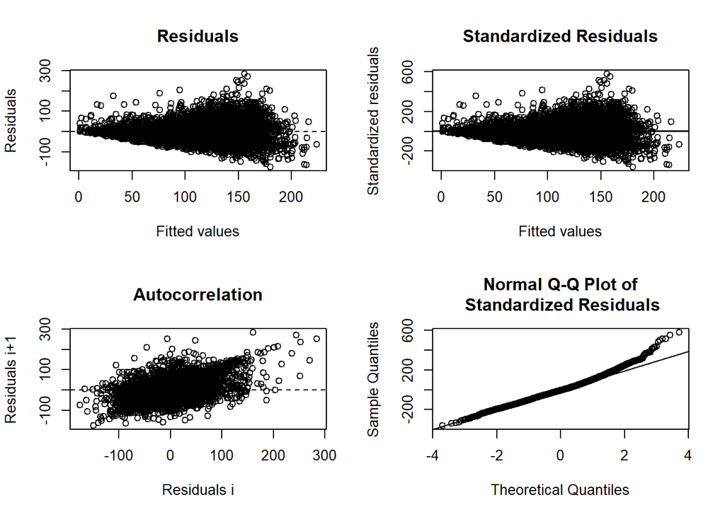

```
##
## ------
##  Shapiro-Wilk normality test
##
## data:  stdres
## W = 0.98603, p-value < 2.2e-16
##
##
## ------
```

```
##
##  Runs Test
##
## data:  as.factor(run)
## Standard Normal = -31.075, p-value < 2.2e-16
## alternative hypothesis: two.sided
```

## predict and plot

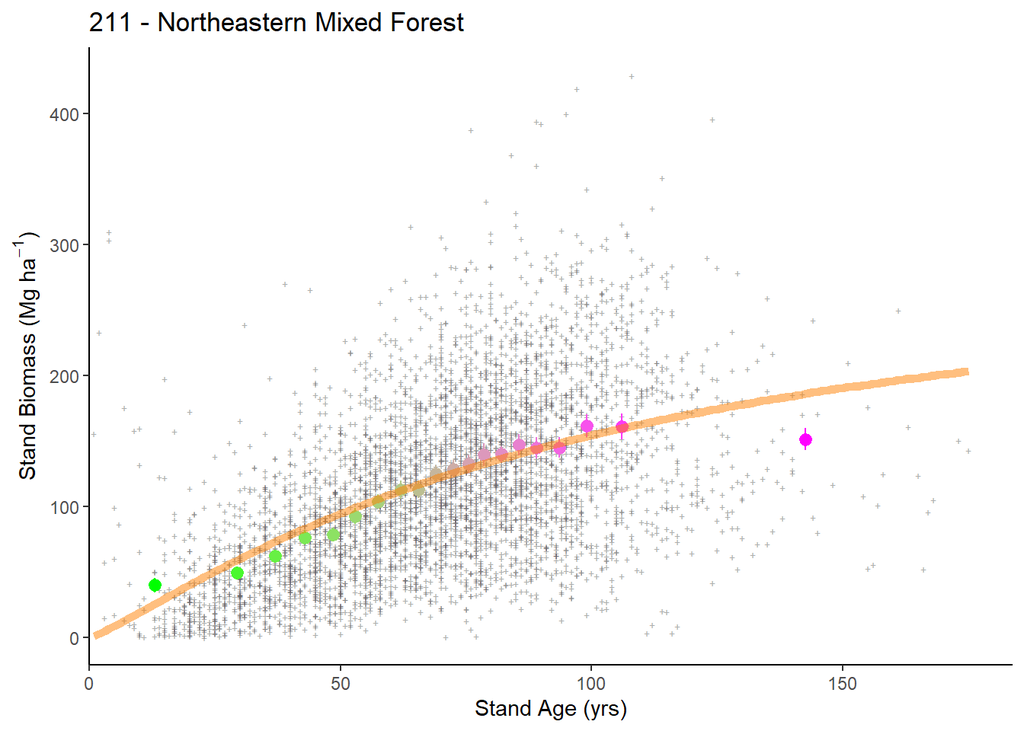

## plotting 2

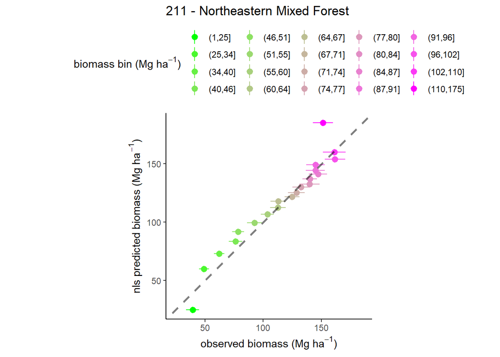

# 212 - Laurentian Mixed Forest

## model selection 1

```
## Analysis of Variance Table
##
## Model 1: B_plt_t2_MgHa ~ (1 + (MEASTIME_t2 - 1990) * ge/100) * A * STDAGE_t2/(k + STDAGE_t2)
## Model 2: B_plt_t2_MgHa ~ (1 + (MEASTIME_t2 - 1990) * ge/100) * (1 + phi * DeltaPDSI) * A * STDAGE_t2/(k + STDAGE_t2)
## Model 3: B_plt_t2_MgHa ~ (1 + (MEASTIME_t2 - 1990) * ge/100) * (1 + phi * DeltaPDSI) * (1 - alpha * B_L_prop) * A * STDAGE_t2/(k + STDAGE_t2)
##   Res.Df Res.Sum Sq Df  Sum Sq  F value Pr(>F)
## 1  11675     4126.4
## 2  11672     4126.4  3   0.012   0.0117 0.9983
## 3  11671     3944.9  1 181.452 536.8233 <2e-16 ***
## ---
## Signif. codes:  0 '***' 0.001 '**' 0.01 '*' 0.05 '.' 0.1 ' ' 1
##   model      AIC
## 1     1 121669.1
## 2     2 121650.8
## 3     3 121127.8
```

```
##
## Formula: B_plt_t2_MgHa ~ (1 + (MEASTIME_t2 - 1990) * ge/100) * (1 + phi *
##     DeltaPDSI) * (1 - alpha * B_L_prop) * A * STDAGE_t2/(k +
##     STDAGE_t2)
##
## Parameters:
##        Estimate Std. Error t value Pr(>|t|)
## ge    5.365e-01  1.287e-01   4.168 3.09e-05 ***
## phi   1.532e-03  4.397e-03   0.348    0.727
## alpha 7.786e-01  3.115e-02  24.995  < 2e-16 ***
## A     1.769e+02  6.147e+00  28.771  < 2e-16 ***
## k     7.183e+01  2.841e+00  25.284  < 2e-16 ***
## ---
## Signif. codes:  0 '***' 0.001 '**' 0.01 '*' 0.05 '.' 0.1 ' ' 1
##
## Residual standard error: 0.5814 on 11671 degrees of freedom
##
## Number of iterations to convergence: 5
## Achieved convergence tolerance: 2.965e-06
##   (12 observations deleted due to missingness)
```

### summary

- simple model: fits
- phi model: fits
- phi-alpha model: fits

## model selection 2

```
## Error in numericDeriv(form[[3L]], names(ind), env, central = nDcentral) :
##   Missing value or an infinity produced when evaluating the model
## Analysis of Variance Table
##
## Model 1: B_plt_t2_MgHa ~ (1 + (MEASTIME_t2 - 1990) * ge/100) * (1 + phi * DeltaPDSI) * (1 - alpha * B_L_prop) * A * STDAGE_t2/(k + STDAGE_t2)
## Model 2: B_plt_t2_MgHa ~ (1 + (MEASTIME_t2 - 1990) * ge/100) * (1 + phi * DeltaPDSI) * (1 - alpha * B_L_prop) * (p * A + ((1 - p) * A * STDAGE_t2/(k + STDAGE_t2)))
##   Res.Df Res.Sum Sq Df Sum Sq F value  Pr(>F)
## 1  11671     3944.9
## 2  11670     3943.8  1 1.1224  3.3212 0.06842 .
## ---
## Signif. codes:  0 '***' 0.001 '**' 0.01 '*' 0.05 '.' 0.1 ' ' 1
##   model      AIC
## 1     3 121127.8
## 2    3a 121126.4
## 3    3b 121119.1
## 4    3c       NA
```

```
##
## Formula: B_plt_t2_MgHa ~ (1 + (MEASTIME_t2 - 1990) * ge/100) * (1 + phi *
##     DeltaPDSI) * (1 - alpha * B_L_prop) * (A * STDAGE_t2^s/(k^s +
##     STDAGE_t2^s))
##
## Parameters:
##        Estimate Std. Error t value Pr(>|t|)
## ge    5.634e-01  1.305e-01   4.316  1.6e-05 ***
## phi   1.383e-03  4.392e-03   0.315    0.753
## alpha 7.821e-01  3.136e-02  24.935  < 2e-16 ***
## A     1.506e+02  8.673e+00  17.367  < 2e-16 ***
## k     5.254e+01  4.899e+00  10.724  < 2e-16 ***
## s     1.140e+00  4.743e-02  24.032  < 2e-16 ***
## ---
## Signif. codes:  0 '***' 0.001 '**' 0.01 '*' 0.05 '.' 0.1 ' ' 1
##
## Residual standard error: 0.5811 on 11670 degrees of freedom
##
## Number of iterations to convergence: 7
## Achieved convergence tolerance: 5.822e-06
##   (12 observations deleted due to missingness)
```

### summary

- add p model: fits
- add s model: fits
- add s+p model: does not fit

## plot residuals

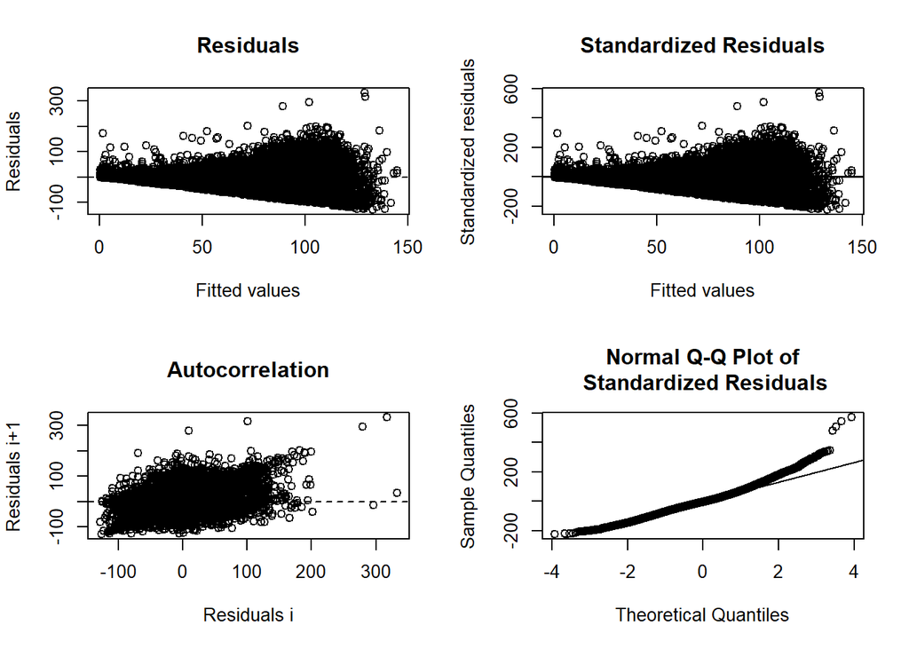

## predict and plot

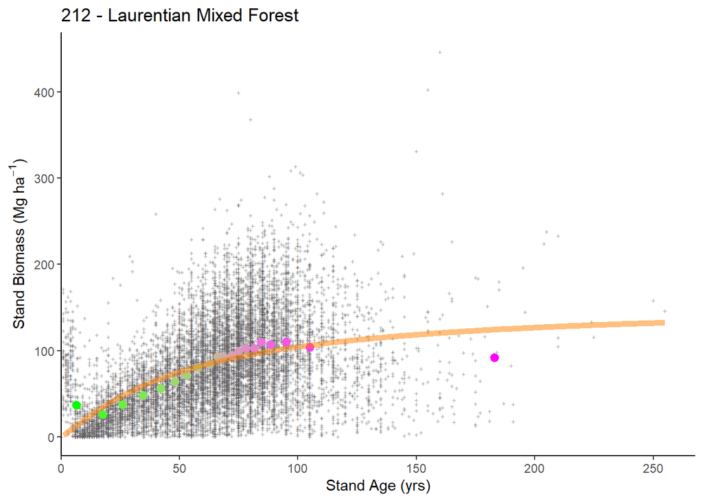

## plotting 2

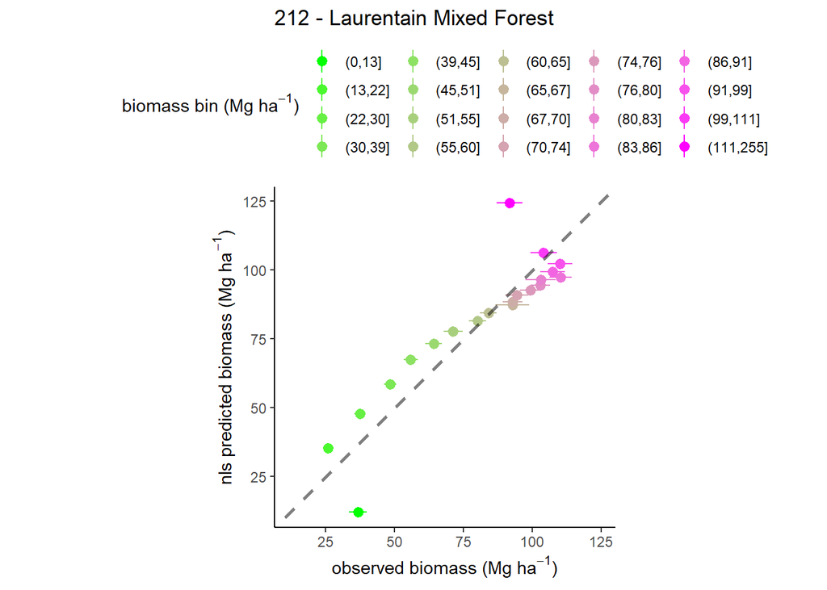

# 221 - Eastern Broadleaf Forest

## model selection 1

```
## Analysis of Variance Table
##
## Model 1: B_plt_t2_MgHa ~ (1 + (MEASTIME_t2 - 1990) * ge/100) * A * STDAGE_t2/(k + STDAGE_t2)
## Model 2: B_plt_t2_MgHa ~ (1 + (MEASTIME_t2 - 1990) * ge/100) * (1 + phi * DeltaPDSI) * A * STDAGE_t2/(k + STDAGE_t2)
## Model 3: B_plt_t2_MgHa ~ (1 + (MEASTIME_t2 - 1990) * ge/100) * (1 + phi * DeltaPDSI) * (1 - alpha * B_L_prop) * A * STDAGE_t2/(k + STDAGE_t2)
##   Res.Df Res.Sum Sq Df Sum Sq F value Pr(>F)
## 1   5346     942.54
## 2   5345     942.37  1   0.17  0.9656 0.3258
## 3   5338     840.60  7 101.77 92.3216 <2e-16 ***
## ---
## Signif. codes:  0 '***' 0.001 '**' 0.01 '*' 0.05 '.' 0.1 ' ' 1
##   model      AIC
## 1     1 58245.33
## 2     2 58246.36
## 3     3 57587.40
```

```
##
## Formula: B_plt_t2_MgHa ~ (1 + (MEASTIME_t2 - 1990) * ge/100) * (1 + phi *
##     DeltaPDSI) * (1 - alpha * B_L_prop) * A * STDAGE_t2/(k +
##     STDAGE_t2)
##
## Parameters:
##         Estimate Std. Error t value Pr(>|t|)
## ge      0.287871   0.139459   2.064    0.039 *
## phi    -0.006857   0.005295  -1.295    0.195
## alpha   0.844533   0.031061  27.190   <2e-16 ***
## A     442.826577  26.199395  16.902   <2e-16 ***
## k     132.566020   9.420885  14.072   <2e-16 ***
## ---
## Signif. codes:  0 '***' 0.001 '**' 0.01 '*' 0.05 '.' 0.1 ' ' 1
##
## Residual standard error: 0.3968 on 5338 degrees of freedom
##
## Number of iterations to convergence: 6
## Achieved convergence tolerance: 4.085e-06
##   (7 observations deleted due to missingness)
```

### summary

- simple model: fits
- phi model: fits
- phi-alpha model: fits

## model selection 2

```
## Error in numericDeriv(form[[3L]], names(ind), env, central = nDcentral) :
##   Missing value or an infinity produced when evaluating the model
## Analysis of Variance Table
##
## Model 1: B_plt_t2_MgHa ~ (1 + (MEASTIME_t2 - 1990) * ge/100) * (1 + phi * DeltaPDSI) * (1 - alpha * B_L_prop) * A * STDAGE_t2/(k + STDAGE_t2)
## Model 2: B_plt_t2_MgHa ~ (1 + (MEASTIME_t2 - 1990) * ge/100) * (1 + phi * DeltaPDSI) * (1 - alpha * B_L_prop) * (p * A + ((1 - p) * A * STDAGE_t2/(k + STDAGE_t2)))
##   Res.Df Res.Sum Sq Df  Sum Sq F value Pr(>F)
## 1   5338     840.60
## 2   5337     840.28  1 0.31561  2.0045 0.1569
##   model      AIC
## 1     3 57587.40
## 2    3a 57587.40
## 3    3b 57572.81
## 4    3c       NA
```

```
##
## Formula: B_plt_t2_MgHa ~ (1 + (MEASTIME_t2 - 1990) * ge/100) * (1 + phi *
##     DeltaPDSI) * (1 - alpha * B_L_prop) * (A * STDAGE_t2^s/(k^s +
##     STDAGE_t2^s))
##
## Parameters:
##         Estimate Std. Error t value Pr(>|t|)
## ge      0.326775   0.142031   2.301   0.0214 *
## phi    -0.007045   0.005280  -1.334   0.1822
## alpha   0.850107   0.031232  27.219   <2e-16 ***
## A     293.391635  23.989381  12.230   <2e-16 ***
## k      65.218739   7.655362   8.519   <2e-16 ***
## s       1.284970   0.072542  17.714   <2e-16 ***
## ---
## Signif. codes:  0 '***' 0.001 '**' 0.01 '*' 0.05 '.' 0.1 ' ' 1
##
## Residual standard error: 0.3963 on 5337 degrees of freedom
##
## Number of iterations to convergence: 6
## Achieved convergence tolerance: 4.746e-06
##   (7 observations deleted due to missingness)
```

### summary

- add p model: fits
- add s model: fits
- add s+p model: does not fit

## plot residuals

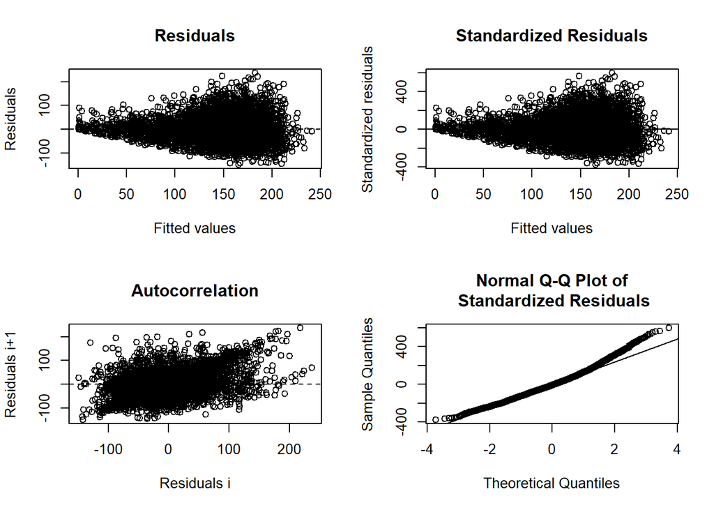

## predict and plot

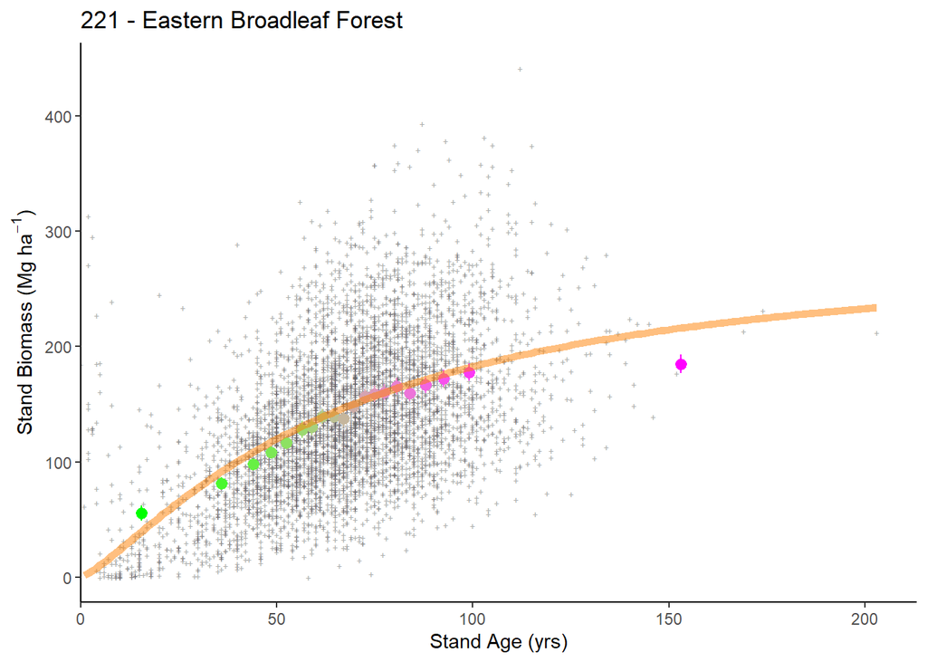

## plotting 2

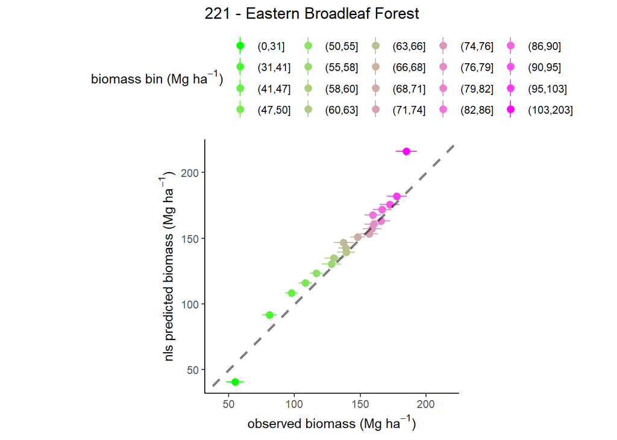

# 222 - Midwest Broadleaf Forest

## model selection 1

```
## Analysis of Variance Table
##
## Model 1: B_plt_t2_MgHa ~ (1 + (MEASTIME_t2 - 1990) * ge/100) * A * STDAGE_t2/(k + STDAGE_t2)
## Model 2: B_plt_t2_MgHa ~ (1 + (MEASTIME_t2 - 1990) * ge/100) * (1 + phi * DeltaPDSI) * A * STDAGE_t2/(k + STDAGE_t2)
## Model 3: B_plt_t2_MgHa ~ (1 + (MEASTIME_t2 - 1990) * ge/100) * (1 + phi * DeltaPDSI) * (1 - alpha * B_L_prop) * A * STDAGE_t2/(k + STDAGE_t2)
##   Res.Df Res.Sum Sq Df Sum Sq F value  Pr(>F)
## 1   3243     1099.5
## 2   3242     1097.4  1  2.125  6.2769 0.01228 *
## 3   3238     1024.7  4 72.654 57.3956 < 2e-16 ***
## ---
## Signif. codes:  0 '***' 0.001 '**' 0.01 '*' 0.05 '.' 0.1 ' ' 1
```

```
##   model      AIC
## 1     1 35070.29
## 2     2 35066.01
## 3     3 34823.82
```

```
##
## Formula: B_plt_t2_MgHa ~ (1 + (MEASTIME_t2 - 1990) * ge/100) * (1 + phi *
##     DeltaPDSI) * (1 - alpha * B_L_prop) * A * STDAGE_t2/(k +
##     STDAGE_t2)
##
## Parameters:
##        Estimate Std. Error t value Pr(>|t|)
## ge     -0.08813    0.22986  -0.383  0.70145
## phi     0.03652    0.01210   3.019  0.00255 **
## alpha   0.85669    0.05167  16.579  < 2e-16 ***
## A     472.15874   52.82341   8.938  < 2e-16 ***
## k     207.16532   26.13658   7.926 3.08e-15 ***
## ---
## Signif. codes:  0 '***' 0.001 '**' 0.01 '*' 0.05 '.' 0.1 ' ' 1
##
## Residual standard error: 0.5626 on 3238 degrees of freedom
##
## Number of iterations to convergence: 7
## Achieved convergence tolerance: 7.071e-06
##   (5 observations deleted due to missingness)
```

### summary

- simple model: fits
- phi model: fits
- phi-alpha model: fits

## model selection 2

```
## Error in numericDeriv(form[[3L]], names(ind), env, central = nDcentral) :
##   Missing value or an infinity produced when evaluating the model
## Error in numericDeriv(form[[3L]], names(ind), env, central = nDcentral) :
##   Missing value or an infinity produced when evaluating the model
## Analysis of Variance Table
##
## Model 1: B_plt_t2_MgHa ~ (1 + (MEASTIME_t2 - 1990) * ge/100) * (1 + phi * DeltaPDSI) * (1 - alpha * B_L_prop) * A * STDAGE_t2/(k + STDAGE_t2)
## Model 2: B_plt_t2_MgHa ~ (1 + (MEASTIME_t2 - 1990) * ge/100) * (1 + phi * DeltaPDSI) * (1 - alpha * B_L_prop) * (p * A + ((1 - p) * A * STDAGE_t2/(k + STDAGE_t2)))
##   Res.Df Res.Sum Sq Df Sum Sq F value  Pr(>F)
## 1   3238     1024.7
## 2   3237     1022.9  1 1.7966  5.6852 0.01717 *
## ---
## Signif. codes:  0 '***' 0.001 '**' 0.01 '*' 0.05 '.' 0.1 ' ' 1
##   model      AIC
## 1     3 34823.82
## 2    3a 34820.13
## 3    3b       NA
## 4    3c       NA
```

```
##
## Formula: B_plt_t2_MgHa ~ (1 + (MEASTIME_t2 - 1990) * ge/100) * (1 + phi *
##     DeltaPDSI) * (1 - alpha * B_L_prop) * (p * A + ((1 - p) *
##     A * STDAGE_t2/(k + STDAGE_t2)))
##
## Parameters:
##        Estimate Std. Error t value Pr(>|t|)
## ge     -0.07123    0.23181  -0.307  0.75865
## phi     0.03630    0.01208   3.004  0.00268 **
## alpha   0.87160    0.05186  16.806  < 2e-16 ***
## A     389.93264   50.23693   7.762 1.11e-14 ***
## k     149.40778   27.98759   5.338 1.00e-07 ***
## p      -0.01742    0.01010  -1.724  0.08474 .
## ---
## Signif. codes:  0 '***' 0.001 '**' 0.01 '*' 0.05 '.' 0.1 ' ' 1
##
## Residual standard error: 0.5621 on 3237 degrees of freedom
##
## Number of iterations to convergence: 9
## Achieved convergence tolerance: 4.847e-06
##   (5 observations deleted due to missingness)
```

### summary

- add p model: fits
- add s model: does not fit
- add s+p model: does not fit

## plot residuals

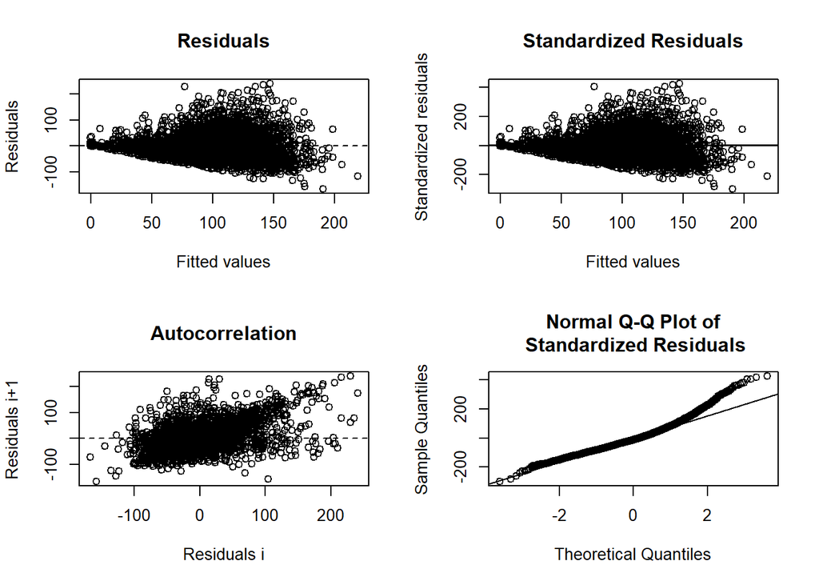

```
##
## ------
##  Shapiro-Wilk normality test
##
## data:  stdres
## W = 0.95899, p-value < 2.2e-16
##
##
## ------
```

```
##
##  Runs Test
##
## data:  as.factor(run)
## Standard Normal = -24.299, p-value < 2.2e-16
## alternative hypothesis: two.sided
```

## predict and plot

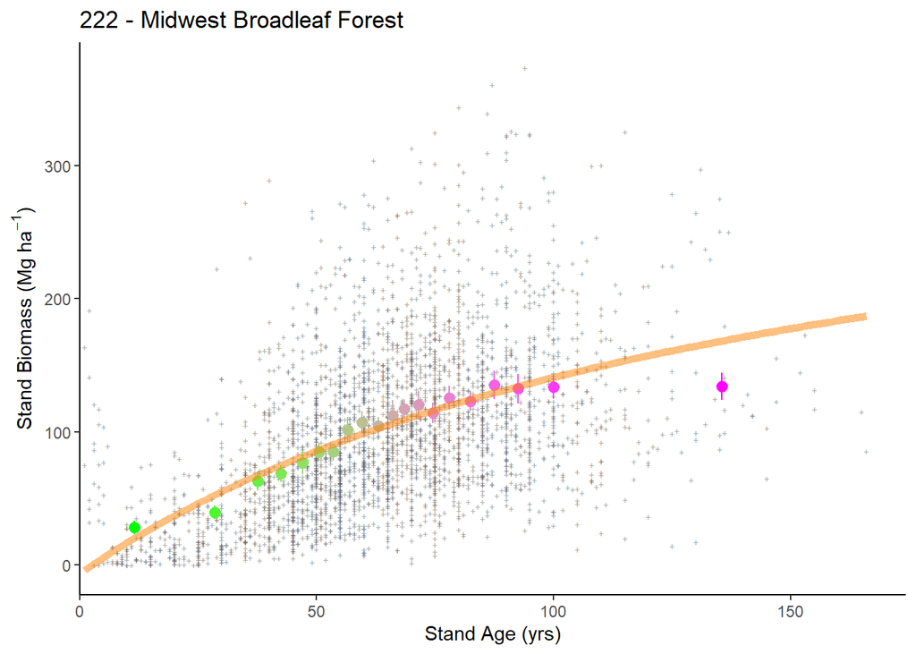

## plotting 2

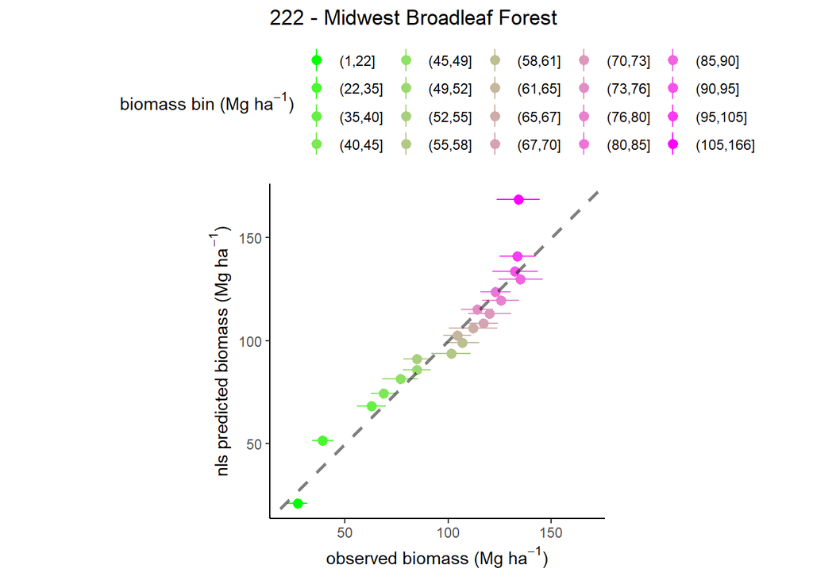

# 223 - Central Interior Broadleaf Forest

## model selection 1

```
## Analysis of Variance Table
##
## Model 1: B_plt_t2_MgHa ~ (1 + (MEASTIME_t2 - 1990) * ge/100) * A * STDAGE_t2/(k + STDAGE_t2)
## Model 2: B_plt_t2_MgHa ~ (1 + (MEASTIME_t2 - 1990) * ge/100) * (1 + phi * DeltaPDSI) * A * STDAGE_t2/(k + STDAGE_t2)
## Model 3: B_plt_t2_MgHa ~ (1 + (MEASTIME_t2 - 1990) * ge/100) * (1 + phi * DeltaPDSI) * (1 - alpha * B_L_prop) * A * STDAGE_t2/(k + STDAGE_t2)
##   Res.Df Res.Sum Sq Df Sum Sq  F value  Pr(>F)
## 1   6038     1221.8
## 2   6037     1221.1  1  0.729   3.6062 0.05761 .
## 3   6034     1125.6  3 95.475 170.6014 < 2e-16 ***
## ---
## Signif. codes:  0 '***' 0.001 '**' 0.01 '*' 0.05 '.' 0.1 ' ' 1
##   model      AIC
## 1     1 63378.09
## 2     2 63376.48
## 3     3 62871.04
```

```
##
## Formula: B_plt_t2_MgHa ~ (1 + (MEASTIME_t2 - 1990) * ge/100) * (1 + phi *
##     DeltaPDSI) * (1 - alpha * B_L_prop) * A * STDAGE_t2/(k +
##     STDAGE_t2)
##
## Parameters:
##         Estimate Std. Error t value Pr(>|t|)
## ge      0.327230   0.133814   2.445   0.0145 *
## phi    -0.012505   0.006218  -2.011   0.0444 *
## alpha   0.774810   0.032049  24.176   <2e-16 ***
## A     235.564930  10.051802  23.435   <2e-16 ***
## k      68.786981   4.010754  17.151   <2e-16 ***
## ---
## Signif. codes:  0 '***' 0.001 '**' 0.01 '*' 0.05 '.' 0.1 ' ' 1
##
## Residual standard error: 0.4319 on 6034 degrees of freedom
##
## Number of iterations to convergence: 6
## Achieved convergence tolerance: 2.214e-06
##   (7 observations deleted due to missingness)
```

### summary

- simple model: fits
- phi model: fits
- phi-alpha model: fits

## model selection 2

```
## Analysis of Variance Table
##
## Model 1: B_plt_t2_MgHa ~ (1 + (MEASTIME_t2 - 1990) * ge/100) * (1 + phi * DeltaPDSI) * (1 - alpha * B_L_prop) * A * STDAGE_t2/(k + STDAGE_t2)
## Model 2: B_plt_t2_MgHa ~ (1 + (MEASTIME_t2 - 1990) * ge/100) * (1 + phi * DeltaPDSI) * (1 - alpha * B_L_prop) * (p * A + ((1 - p) * A * STDAGE_t2/(k + STDAGE_t2)))
## Model 3: B_plt_t2_MgHa ~ (1 + (MEASTIME_t2 - 1990) * ge/100) * (1 + phi * DeltaPDSI) * (1 - alpha * B_L_prop) * (A * STDAGE_t2^s/(k^s + STDAGE_t2^s))
## Model 4: B_plt_t2_MgHa ~ (1 + (MEASTIME_t2 - 1990) * ge/100) * (1 + phi * DeltaPDSI) * (1 - alpha * B_L_prop) * (p * A + ((1 - p) * A * STDAGE_t2^s/(k^s + STDAGE_t2^s)))
##   Res.Df Res.Sum Sq Df  Sum Sq F value    Pr(>F)
## 1   6034     1125.6
## 2   6033     1125.6  1  0.0049  0.0261    0.8717
## 3   6033     1123.3  0  0.0000
## 4   6032     1112.6  1 10.6793 57.8985 3.184e-14 ***
## ---
## Signif. codes:  0 '***' 0.001 '**' 0.01 '*' 0.05 '.' 0.1 ' ' 1
##   model      AIC
## 1     3 62871.04
## 2    3a 62873.02
## 3    3b 62860.47
## 4    3c 62804.78
```

```
##
## Formula: B_plt_t2_MgHa ~ (1 + (MEASTIME_t2 - 1990) * ge/100) * (1 + phi *
##     DeltaPDSI) * (1 - alpha * B_L_prop) * (p * A + ((1 - p) *
##     A * STDAGE_t2^s/(k^s + STDAGE_t2^s)))
##
## Parameters:
##         Estimate Std. Error t value Pr(>|t|)
## ge      0.333395   0.133560   2.496   0.0126 *
## phi    -0.010383   0.006196  -1.676   0.0938 .
## alpha   0.778726   0.031477  24.739   <2e-16 ***
## A     143.832060   5.642296  25.492   <2e-16 ***
## k      40.729115   1.357102  30.012   <2e-16 ***
## p       0.219645   0.024818   8.850   <2e-16 ***
## s       2.477472   0.216762  11.429   <2e-16 ***
## ---
## Signif. codes:  0 '***' 0.001 '**' 0.01 '*' 0.05 '.' 0.1 ' ' 1
##
## Residual standard error: 0.4295 on 6032 degrees of freedom
##
## Number of iterations to convergence: 9
## Achieved convergence tolerance: 2.738e-06
##   (7 observations deleted due to missingness)
```

### summary

- add p model: fits
- add s model: fits
- add s+p model: fits

## plot residuals

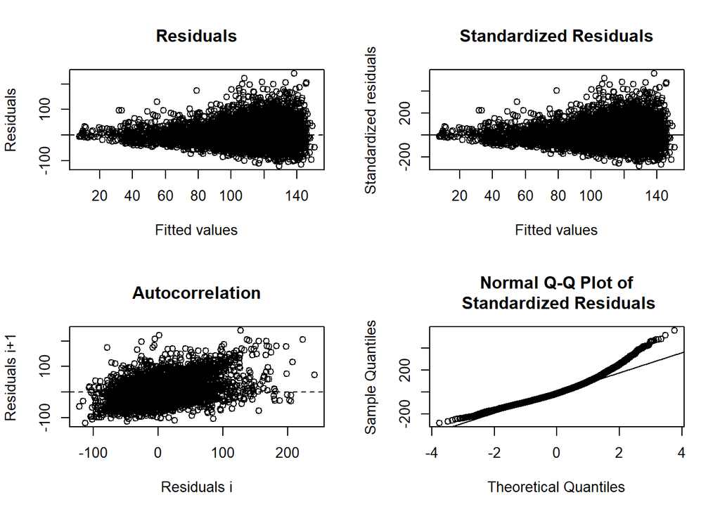

## predict and plot

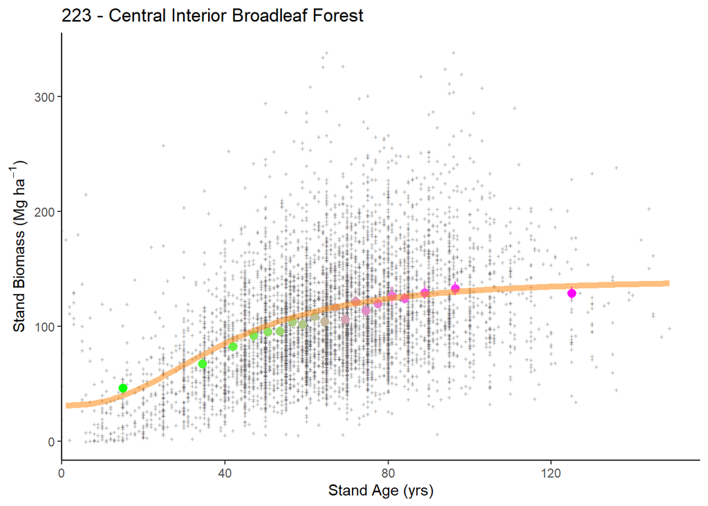

## plotting 2

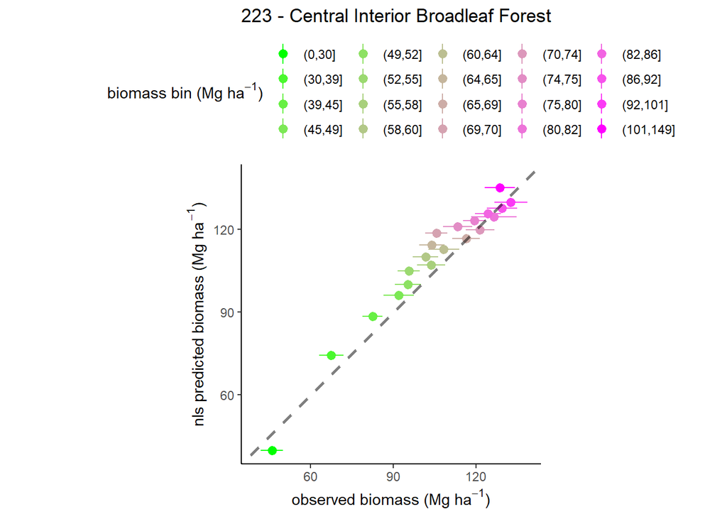

# 231 - Southeastern Mixed Forest

## model selection 1

```
## Analysis of Variance Table
##
## Model 1: B_plt_t2_MgHa ~ (1 + (MEASTIME_t2 - 1990) * ge/100) * A * STDAGE_t2/(k + STDAGE_t2)
## Model 2: B_plt_t2_MgHa ~ (1 + (MEASTIME_t2 - 1990) * ge/100) * (1 + phi * DeltaPDSI) * A * STDAGE_t2/(k + STDAGE_t2)
## Model 3: B_plt_t2_MgHa ~ (1 + (MEASTIME_t2 - 1990) * ge/100) * (1 + phi * DeltaPDSI) * (1 - alpha * B_L_prop) * A * STDAGE_t2/(k + STDAGE_t2)
##   Res.Df Res.Sum Sq Df  Sum Sq F value Pr(>F)
## 1   7523     2246.9
## 2   7522     2246.2  1   0.783   2.621 0.1055
## 3   7521     2048.6  1 197.582 725.390 <2e-16 ***
## ---
## Signif. codes:  0 '***' 0.001 '**' 0.01 '*' 0.05 '.' 0.1 ' ' 1
##   model      AIC
## 1     1 81439.99
## 2     2 81439.37
## 3     3 80748.40
```

```
##
## Formula: B_plt_t2_MgHa ~ (1 + (MEASTIME_t2 - 1990) * ge/100) * (1 + phi *
##     DeltaPDSI) * (1 - alpha * B_L_prop) * A * STDAGE_t2/(k +
##     STDAGE_t2)
##
## Parameters:
##         Estimate Std. Error t value Pr(>|t|)
## ge      1.424350   0.144941   9.827   <2e-16 ***
## phi    -0.007896   0.005137  -1.537    0.124
## alpha   0.751424   0.025936  28.972   <2e-16 ***
## A     258.093228   9.310142  27.722   <2e-16 ***
## k      69.090766   2.564279  26.944   <2e-16 ***
## ---
## Signif. codes:  0 '***' 0.001 '**' 0.01 '*' 0.05 '.' 0.1 ' ' 1
##
## Residual standard error: 0.5219 on 7521 degrees of freedom
##
## Number of iterations to convergence: 6
## Achieved convergence tolerance: 1.461e-06
##   (6 observations deleted due to missingness)
```

### summary

- simple model: fits
- phi model: fits
- phi-alpha model: fits

## model selection 2

```
## Analysis of Variance Table
##
## Model 1: B_plt_t2_MgHa ~ (1 + (MEASTIME_t2 - 1990) * ge/100) * (1 + phi * DeltaPDSI) * (1 - alpha * B_L_prop) * A * STDAGE_t2/(k + STDAGE_t2)
## Model 2: B_plt_t2_MgHa ~ (1 + (MEASTIME_t2 - 1990) * ge/100) * (1 + phi * DeltaPDSI) * (1 - alpha * B_L_prop) * (p * A + ((1 - p) * A * STDAGE_t2/(k + STDAGE_t2)))
## Model 3: B_plt_t2_MgHa ~ (1 + (MEASTIME_t2 - 1990) * ge/100) * (1 + phi * DeltaPDSI) * (1 - alpha * B_L_prop) * (A * STDAGE_t2^s/(k^s + STDAGE_t2^s))
## Model 4: B_plt_t2_MgHa ~ (1 + (MEASTIME_t2 - 1990) * ge/100) * (1 + phi * DeltaPDSI) * (1 - alpha * B_L_prop) * (p * A + ((1 - p) * A * STDAGE_t2^s/(k^s + STDAGE_t2^s)))
##   Res.Df Res.Sum Sq Df Sum Sq F value    Pr(>F)
## 1   7521     2048.6
## 2   7520     2046.3  1 2.3021  8.4603  0.003641 **
## 3   7520     2041.7  0 0.0000
## 4   7519     2036.4  1 5.2988 19.5647 9.862e-06 ***
## ---
## Signif. codes:  0 '***' 0.001 '**' 0.01 '*' 0.05 '.' 0.1 ' ' 1
##   model      AIC
## 1     3 80748.40
## 2    3a 80741.94
## 3    3b 80725.14
## 4    3c 80707.58
```

```
##
## Formula: B_plt_t2_MgHa ~ (1 + (MEASTIME_t2 - 1990) * ge/100) * (1 + phi *
##     DeltaPDSI) * (1 - alpha * B_L_prop) * (p * A + ((1 - p) *
##     A * STDAGE_t2^s/(k^s + STDAGE_t2^s)))
##
## Parameters:
##         Estimate Std. Error t value Pr(>|t|)
## ge      1.474786   0.147660   9.988  < 2e-16 ***
## phi    -0.009110   0.005125  -1.778   0.0755 .
## alpha   0.757044   0.025665  29.498  < 2e-16 ***
## A     158.979723   7.855788  20.237  < 2e-16 ***
## k      32.983883   1.601156  20.600  < 2e-16 ***
## p       0.086428   0.020531   4.210 2.59e-05 ***
## s       1.669672   0.126707  13.177  < 2e-16 ***
## ---
## Signif. codes:  0 '***' 0.001 '**' 0.01 '*' 0.05 '.' 0.1 ' ' 1
##
## Residual standard error: 0.5204 on 7519 degrees of freedom
##
## Number of iterations to convergence: 11
## Achieved convergence tolerance: 6.424e-06
##   (6 observations deleted due to missingness)
```

### summary

- add p model: fits
- add s model: fits
- add s+p model: fits

## plot residuals

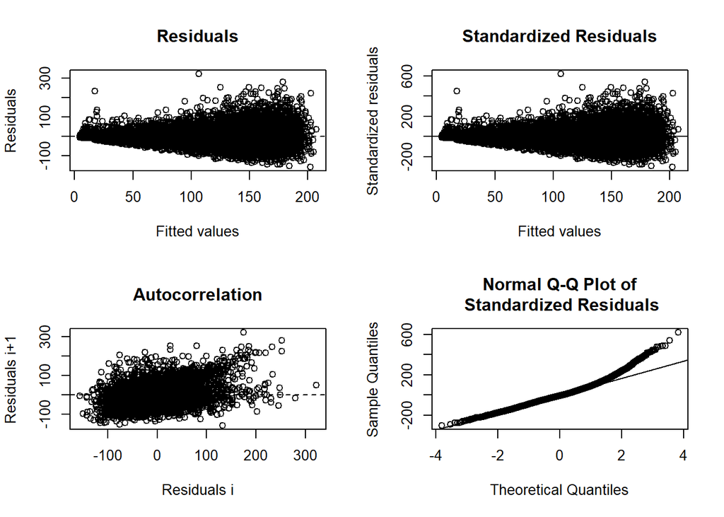

## predict and plot

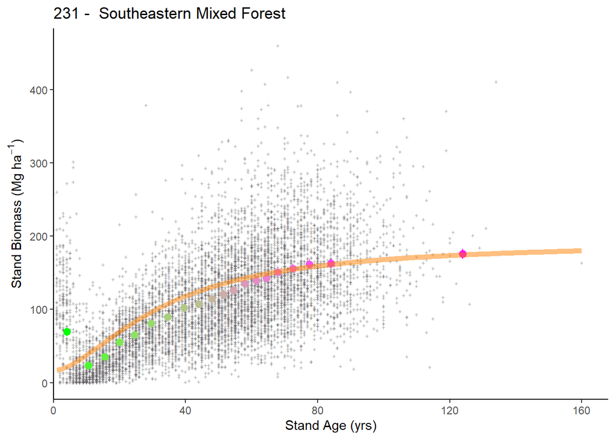

## plotting 2

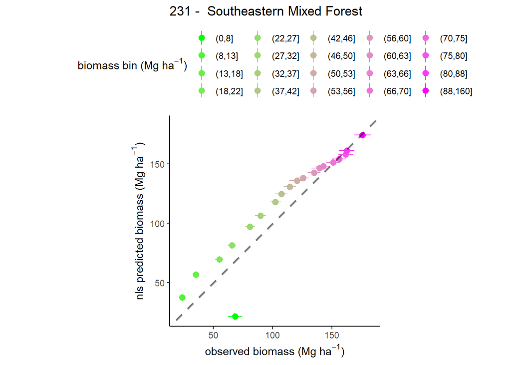

# 232 - Outer Coastal Plain Mixed Forest

## model selection 1

```
## Analysis of Variance Table
##
## Model 1: B_plt_t2_MgHa ~ (1 + (MEASTIME_t2 - 1990) * ge/100) * A * STDAGE_t2/(k + STDAGE_t2)
## Model 2: B_plt_t2_MgHa ~ (1 + (MEASTIME_t2 - 1990) * ge/100) * (1 + phi * DeltaPDSI) * A * STDAGE_t2/(k + STDAGE_t2)
## Model 3: B_plt_t2_MgHa ~ (1 + (MEASTIME_t2 - 1990) * ge/100) * (1 + phi * DeltaPDSI) * (1 - alpha * B_L_prop) * A * STDAGE_t2/(k + STDAGE_t2)
##   Res.Df Res.Sum Sq Df  Sum Sq F value    Pr(>F)
## 1   7554     3411.4
## 2   7553     3400.7  1  10.732  23.835 1.071e-06 ***
## 3   7552     3202.3  1 198.397 467.887 < 2.2e-16 ***
## ---
## Signif. codes:  0 '***' 0.001 '**' 0.01 '*' 0.05 '.' 0.1 ' ' 1
##   model      AIC
## 1     1 83949.22
## 2     2 83927.41
## 3     3 83475.14
```

```
##
## Formula: B_plt_t2_MgHa ~ (1 + (MEASTIME_t2 - 1990) * ge/100) * (1 + phi *
##     DeltaPDSI) * (1 - alpha * B_L_prop) * A * STDAGE_t2/(k +
##     STDAGE_t2)
##
## Parameters:
##        Estimate Std. Error t value Pr(>|t|)
## ge    9.686e-01  1.597e-01   6.065 1.38e-09 ***
## phi   2.944e-02  6.574e-03   4.478 7.64e-06 ***
## alpha 7.367e-01  3.157e-02  23.331  < 2e-16 ***
## A     2.490e+02  1.089e+01  22.875  < 2e-16 ***
## k     6.283e+01  2.879e+00  21.823  < 2e-16 ***
## ---
## Signif. codes:  0 '***' 0.001 '**' 0.01 '*' 0.05 '.' 0.1 ' ' 1
##
## Residual standard error: 0.6512 on 7552 degrees of freedom
##
## Number of iterations to convergence: 6
## Achieved convergence tolerance: 7.592e-07
##   (11 observations deleted due to missingness)
```

### summary

- simple model: fits
- phi model: fits
- phi-alpha model: fits

## model selection 2

```
## Analysis of Variance Table
##
## Model 1: B_plt_t2_MgHa ~ (1 + (MEASTIME_t2 - 1990) * ge/100) * (1 + phi * DeltaPDSI) * (1 - alpha * B_L_prop) * A * STDAGE_t2/(k + STDAGE_t2)
## Model 2: B_plt_t2_MgHa ~ (1 + (MEASTIME_t2 - 1990) * ge/100) * (1 + phi * DeltaPDSI) * (1 - alpha * B_L_prop) * (p * A + ((1 - p) * A * STDAGE_t2/(k + STDAGE_t2)))
## Model 3: B_plt_t2_MgHa ~ (1 + (MEASTIME_t2 - 1990) * ge/100) * (1 + phi * DeltaPDSI) * (1 - alpha * B_L_prop) * (A * STDAGE_t2^s/(k^s + STDAGE_t2^s))
## Model 4: B_plt_t2_MgHa ~ (1 + (MEASTIME_t2 - 1990) * ge/100) * (1 + phi * DeltaPDSI) * (1 - alpha * B_L_prop) * (p * A + ((1 - p) * A * STDAGE_t2^s/(k^s + STDAGE_t2^s)))
##   Res.Df Res.Sum Sq Df  Sum Sq F value  Pr(>F)
## 1   7552     3202.3
## 2   7551     3201.9  1 0.32244  0.7604 0.38323
## 3   7551     3200.9  0 0.00000
## 4   7550     3199.2  1 1.67429  3.9513 0.04687 *
## ---
## Signif. codes:  0 '***' 0.001 '**' 0.01 '*' 0.05 '.' 0.1 ' ' 1
##   model      AIC
## 1     3 83475.14
## 2    3a 83476.38
## 3    3b 83473.90
## 4    3c 83471.95
```

```
##
## Formula: B_plt_t2_MgHa ~ (1 + (MEASTIME_t2 - 1990) * ge/100) * (1 + phi *
##     DeltaPDSI) * (1 - alpha * B_L_prop) * (p * A + ((1 - p) *
##     A * STDAGE_t2^s/(k^s + STDAGE_t2^s)))
##
## Parameters:
##        Estimate Std. Error t value Pr(>|t|)
## ge    9.770e-01  1.603e-01   6.094 1.16e-09 ***
## phi   2.996e-02  6.578e-03   4.555 5.32e-06 ***
## alpha 7.397e-01  3.147e-02  23.501  < 2e-16 ***
## A     1.869e+02  1.609e+01  11.619  < 2e-16 ***
## k     3.998e+01  4.204e+00   9.510  < 2e-16 ***
## p     5.451e-02  3.122e-02   1.746   0.0809 .
## s     1.354e+00  1.592e-01   8.503  < 2e-16 ***
## ---
## Signif. codes:  0 '***' 0.001 '**' 0.01 '*' 0.05 '.' 0.1 ' ' 1
##
## Residual standard error: 0.651 on 7550 degrees of freedom
##
## Number of iterations to convergence: 13
## Achieved convergence tolerance: 4.884e-06
##   (11 observations deleted due to missingness)
```

### summary

- add p model: fits
- add s model: fits
- add s+p model: fits

## plot residuals

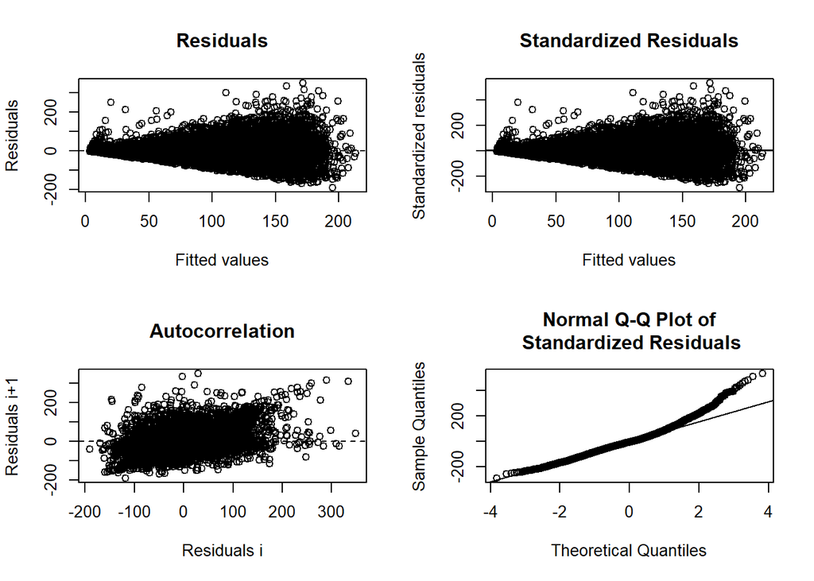

## predict and plot

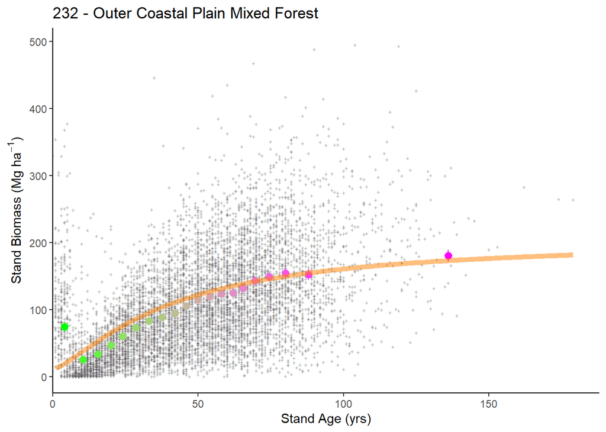

## plotting 2

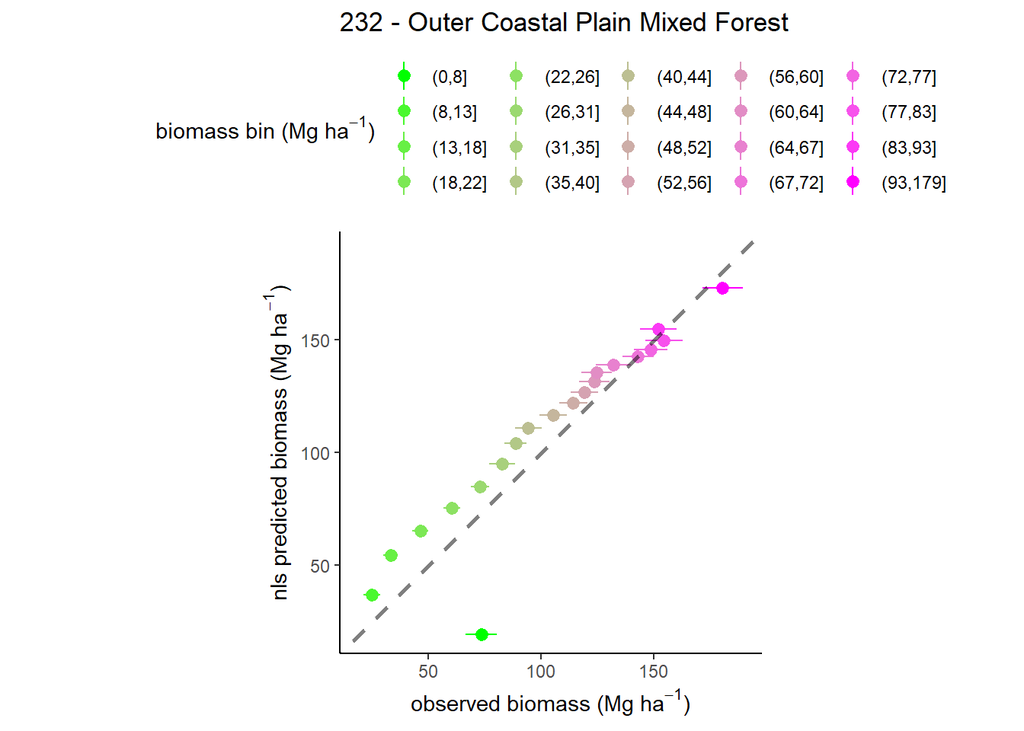

# 234 - Lower Mississippi Riverine Forest

## model selection 1

```
## Analysis of Variance Table
##
## Model 1: B_plt_t2_MgHa ~ (1 + (MEASTIME_t2 - 1990) * ge/100) * A * STDAGE_t2/(k + STDAGE_t2)
## Model 2: B_plt_t2_MgHa ~ (1 + (MEASTIME_t2 - 1990) * ge/100) * (1 + phi * DeltaPDSI) * A * STDAGE_t2/(k + STDAGE_t2)
## Model 3: B_plt_t2_MgHa ~ (1 + (MEASTIME_t2 - 1990) * ge/100) * (1 + phi * DeltaPDSI) * (1 - alpha * B_L_prop) * A * STDAGE_t2/(k + STDAGE_t2)
##   Res.Df Res.Sum Sq Df  Sum Sq  F value Pr(>F)
## 1    779     227.89
## 2    778     227.88  1  0.0072   0.0245 0.8756
## 3    777     197.97  1 29.9088 117.3838 <2e-16 ***
## ---
## Signif. codes:  0 '***' 0.001 '**' 0.01 '*' 0.05 '.' 0.1 ' ' 1
##   model      AIC
## 1     1 8675.522
## 2     2 8677.497
## 3     3 8569.474
```

```
##
## Formula: B_plt_t2_MgHa ~ (1 + (MEASTIME_t2 - 1990) * ge/100) * (1 + phi *
##     DeltaPDSI) * (1 - alpha * B_L_prop) * A * STDAGE_t2/(k +
##     STDAGE_t2)
##
## Parameters:
##        Estimate Std. Error t value Pr(>|t|)
## ge    3.743e-01  5.316e-01   0.704    0.482
## phi   8.263e-03  2.289e-02   0.361    0.718
## alpha 8.132e-01  6.733e-02  12.079  < 2e-16 ***
## A     5.094e+02  1.128e+02   4.515 7.30e-06 ***
## k     1.590e+02  3.986e+01   3.988 7.29e-05 ***
## ---
## Signif. codes:  0 '***' 0.001 '**' 0.01 '*' 0.05 '.' 0.1 ' ' 1
##
## Residual standard error: 0.5048 on 777 degrees of freedom
##
## Number of iterations to convergence: 6
## Achieved convergence tolerance: 3.132e-06
##   (2 observations deleted due to missingness)
```

### summary

- simple model: fits
- phi model: fits
- phi-alpha model: fits

## model selection 2

```
## Error in nls(get(paste("f_", Mod.Sel1, "c", sep = "")), data = G_234,  :
##   step factor 0.000488281 reduced below 'minFactor' of 0.000976562
## Analysis of Variance Table
##
## Model 1: B_plt_t2_MgHa ~ (1 + (MEASTIME_t2 - 1990) * ge/100) * (1 + phi * DeltaPDSI) * (1 - alpha * B_L_prop) * A * STDAGE_t2/(k + STDAGE_t2)
## Model 2: B_plt_t2_MgHa ~ (1 + (MEASTIME_t2 - 1990) * ge/100) * (1 + phi * DeltaPDSI) * (1 - alpha * B_L_prop) * (p * A + ((1 - p) * A * STDAGE_t2/(k + STDAGE_t2)))
##   Res.Df Res.Sum Sq Df  Sum Sq F value Pr(>F)
## 1    777     197.97
## 2    776     197.94  1 0.03087   0.121  0.728
##   model      AIC
## 1     3 8569.474
## 2    3a 8571.352
## 3    3b 8570.712
## 4    3c       NA
```

```
##
## Formula: B_plt_t2_MgHa ~ (1 + (MEASTIME_t2 - 1990) * ge/100) * (1 + phi *
##     DeltaPDSI) * (1 - alpha * B_L_prop) * A * STDAGE_t2/(k +
##     STDAGE_t2)
##
## Parameters:
##        Estimate Std. Error t value Pr(>|t|)
## ge    3.743e-01  5.316e-01   0.704    0.482
## phi   8.263e-03  2.289e-02   0.361    0.718
## alpha 8.132e-01  6.733e-02  12.079  < 2e-16 ***
## A     5.094e+02  1.128e+02   4.515 7.30e-06 ***
## k     1.590e+02  3.986e+01   3.988 7.29e-05 ***
## ---
## Signif. codes:  0 '***' 0.001 '**' 0.01 '*' 0.05 '.' 0.1 ' ' 1
##
## Residual standard error: 0.5048 on 777 degrees of freedom
##
## Number of iterations to convergence: 6
## Achieved convergence tolerance: 3.132e-06
##   (2 observations deleted due to missingness)
```

### summary

- add p model: fits
- add s model: fits
- add s+p model: does not fit

## plot residuals

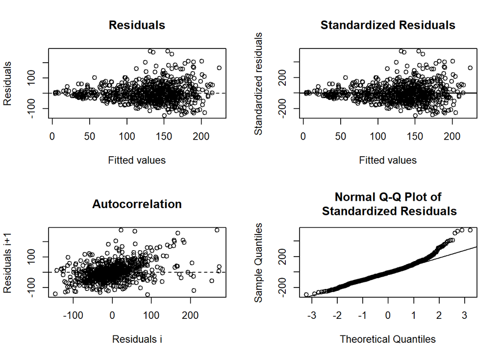

```
##
## ------
##  Shapiro-Wilk normality test
##
## data:  stdres
## W = 0.9542, p-value = 7.008e-15
##
##
## ------
```

```
##
##  Runs Test
##
## data:  as.factor(run)
## Standard Normal = -9.2161, p-value < 2.2e-16
## alternative hypothesis: two.sided
```

## predict and plot

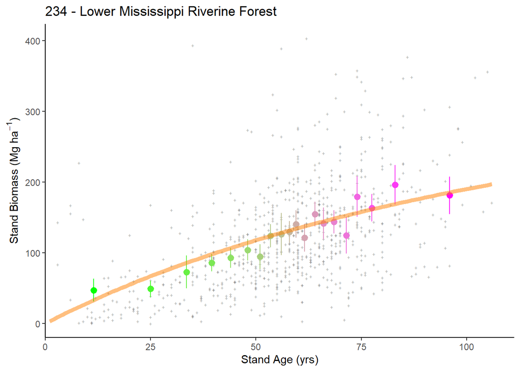

## plotting 2

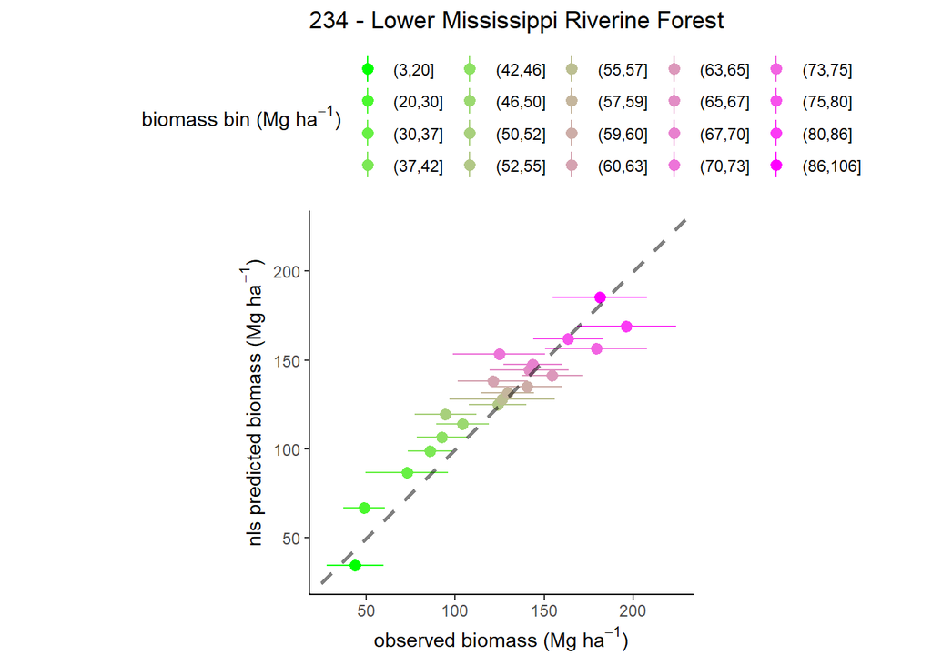

# 242 - Pacific Lowland Mixed Forest

## model selection 1

[output not shown]

```
## Error in h(simpleError(msg, call)) :
##   error in evaluating the argument 'object' in selecting a method for function 'summary': object 'nls_242.' not found
```

### summary

- simple model: does not fit
- phi model: does not fit
- phi-alpha model: does not fit

## model selection 2

### summary

- add p model: does not fit
- add s model: does not fit
- add s+p model: does not fit

## plot residuals

```
## [1] "cannot plot residuals"
```

## predict and plot

```
## [1] "cannot plot data with prediction"
```

## plotting 2

```
## [1] "cannot plot observed vs. predicted"
```

# 251 - Prairie Parkland (Temperate)

## model selection 1

```
## Analysis of Variance Table
##
## Model 1: B_plt_t2_MgHa ~ (1 + (MEASTIME_t2 - 1990) * ge/100) * A * STDAGE_t2/(k + STDAGE_t2)
## Model 2: B_plt_t2_MgHa ~ (1 + (MEASTIME_t2 - 1990) * ge/100) * (1 + phi * DeltaPDSI) * A * STDAGE_t2/(k + STDAGE_t2)
## Model 3: B_plt_t2_MgHa ~ (1 + (MEASTIME_t2 - 1990) * ge/100) * (1 + phi * DeltaPDSI) * (1 - alpha * B_L_prop) * A * STDAGE_t2/(k + STDAGE_t2)
##   Res.Df Res.Sum Sq Df  Sum Sq F value    Pr(>F)
## 1   1244     294.71
## 2   1243     294.64  1  0.0723   0.305    0.5809
## 3   1242     279.84  1 14.7974  65.674 1.262e-15 ***
## ---
## Signif. codes:  0 '***' 0.001 '**' 0.01 '*' 0.05 '.' 0.1 ' ' 1
##   model      AIC
## 1     1 12989.14
## 2     2 12990.83
## 3     3 12928.58
```

```
##
## Formula: B_plt_t2_MgHa ~ (1 + (MEASTIME_t2 - 1990) * ge/100) * (1 + phi *
##     DeltaPDSI) * (1 - alpha * B_L_prop) * A * STDAGE_t2/(k +
##     STDAGE_t2)
##
## Parameters:
##        Estimate Std. Error t value Pr(>|t|)
## ge      0.59358    0.41560   1.428    0.153
## phi    -0.01566    0.01421  -1.102    0.271
## alpha   0.70061    0.08037   8.717  < 2e-16 ***
## A     248.08986   30.16247   8.225 4.87e-16 ***
## k      99.72595   13.70032   7.279 5.94e-13 ***
## ---
## Signif. codes:  0 '***' 0.001 '**' 0.01 '*' 0.05 '.' 0.1 ' ' 1
##
## Residual standard error: 0.4747 on 1242 degrees of freedom
##
## Number of iterations to convergence: 5
## Achieved convergence tolerance: 8.239e-06
##   (1 observation deleted due to missingness)
```

### summary

- simple model: fits
- phi model: fits
- phi-alpha model: fits

## model selection 2

```
## Error in numericDeriv(form[[3L]], names(ind), env, central = nDcentral) :
##   Missing value or an infinity produced when evaluating the model
## Analysis of Variance Table
##
## Model 1: B_plt_t2_MgHa ~ (1 + (MEASTIME_t2 - 1990) * ge/100) * (1 + phi * DeltaPDSI) * (1 - alpha * B_L_prop) * A * STDAGE_t2/(k + STDAGE_t2)
## Model 2: B_plt_t2_MgHa ~ (1 + (MEASTIME_t2 - 1990) * ge/100) * (1 + phi * DeltaPDSI) * (1 - alpha * B_L_prop) * (p * A + ((1 - p) * A * STDAGE_t2/(k + STDAGE_t2)))
##   Res.Df Res.Sum Sq Df  Sum Sq F value  Pr(>F)
## 1   1242     279.84
## 2   1241     278.84  1 0.99873  4.4449 0.03521 *
## ---
## Signif. codes:  0 '***' 0.001 '**' 0.01 '*' 0.05 '.' 0.1 ' ' 1
##   model      AIC
## 1     3 12928.58
## 2    3a 12926.12
## 3    3b 12916.85
## 4    3c       NA
```

```
##
## Formula: B_plt_t2_MgHa ~ (1 + (MEASTIME_t2 - 1990) * ge/100) * (1 + phi *
##     DeltaPDSI) * (1 - alpha * B_L_prop) * (A * STDAGE_t2^s/(k^s +
##     STDAGE_t2^s))
##
## Parameters:
##        Estimate Std. Error t value Pr(>|t|)
## ge      0.60241    0.41491   1.452    0.147
## phi    -0.01500    0.01424  -1.054    0.292
## alpha   0.71285    0.08059   8.845   <2e-16 ***
## A     143.33395   16.38804   8.746   <2e-16 ***
## k      39.23881    4.42339   8.871   <2e-16 ***
## s       1.69196    0.19695   8.591   <2e-16 ***
## ---
## Signif. codes:  0 '***' 0.001 '**' 0.01 '*' 0.05 '.' 0.1 ' ' 1
##
## Residual standard error: 0.4723 on 1241 degrees of freedom
##
## Number of iterations to convergence: 7
## Achieved convergence tolerance: 3.333e-06
##   (1 observation deleted due to missingness)
```

### summary

- add p model: fits
- add s model: fits
- add s+p model: does not fit

## plot residuals

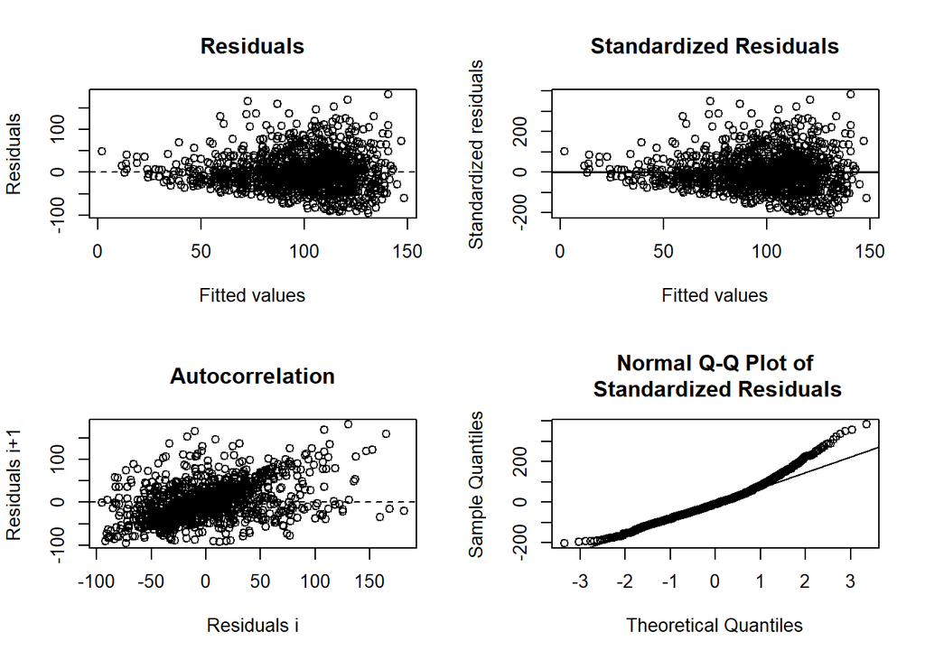

```
##
## ------
##  Shapiro-Wilk normality test
##
## data:  stdres
## W = 0.96845, p-value = 7.663e-16
##
##
## ------
```

```
##
##  Runs Test
##
## data:  as.factor(run)
## Standard Normal = -12.869, p-value < 2.2e-16
## alternative hypothesis: two.sided
```

## predict and plot

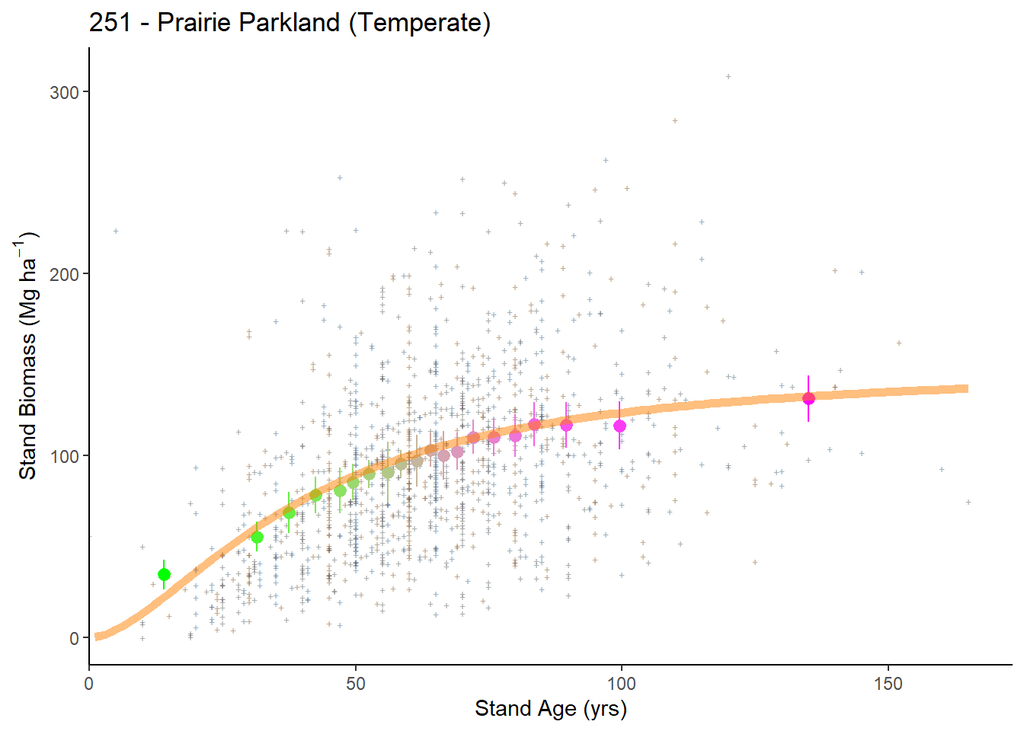

## plotting 2

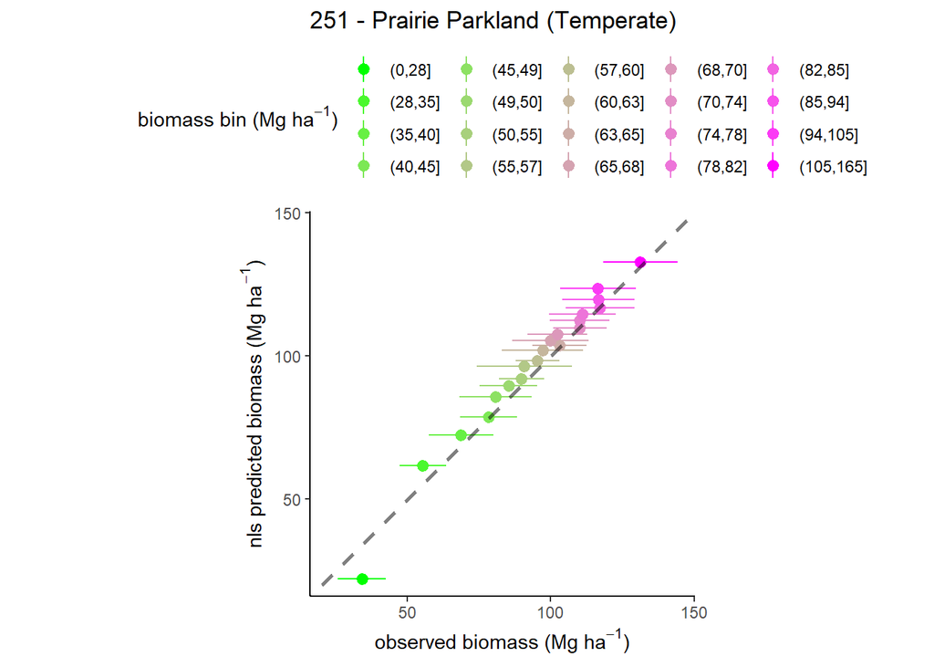

# 255 - Prairie Parkland (Subtropical)

## model selection 1

```
## Analysis of Variance Table
##
## Model 1: B_plt_t2_MgHa ~ (1 + (MEASTIME_t2 - 1990) * ge/100) * A * STDAGE_t2/(k + STDAGE_t2)
## Model 2: B_plt_t2_MgHa ~ (1 + (MEASTIME_t2 - 1990) * ge/100) * (1 + phi * DeltaPDSI) * A * STDAGE_t2/(k + STDAGE_t2)
## Model 3: B_plt_t2_MgHa ~ (1 + (MEASTIME_t2 - 1990) * ge/100) * (1 + phi * DeltaPDSI) * (1 - alpha * B_L_prop) * A * STDAGE_t2/(k + STDAGE_t2)
##   Res.Df Res.Sum Sq Df Sum Sq F value    Pr(>F)
## 1    405     141.13
## 2    404     141.12  1 0.0101  0.0288    0.8653
## 3    403     131.13  1 9.9904 30.7039 5.438e-08 ***
## ---
## Signif. codes:  0 '***' 0.001 '**' 0.01 '*' 0.05 '.' 0.1 ' ' 1
##   model      AIC
## 1     1 4146.872
## 2     2 4148.843
## 3     3 4120.886
```

```
##
## Formula: B_plt_t2_MgHa ~ (1 + (MEASTIME_t2 - 1990) * ge/100) * (1 + phi *
##     DeltaPDSI) * (1 - alpha * B_L_prop) * A * STDAGE_t2/(k +
##     STDAGE_t2)
##
## Parameters:
##        Estimate Std. Error t value Pr(>|t|)
## ge      0.11582    0.49294   0.235    0.814
## phi    -0.02772    0.03636  -0.763    0.446
## alpha   0.80058    0.13009   6.154 1.82e-09 ***
## A     169.21022   28.51360   5.934 6.36e-09 ***
## k      47.54576   10.60780   4.482 9.64e-06 ***
## ---
## Signif. codes:  0 '***' 0.001 '**' 0.01 '*' 0.05 '.' 0.1 ' ' 1
##
## Residual standard error: 0.5704 on 403 degrees of freedom
##
## Number of iterations to convergence: 6
## Achieved convergence tolerance: 9.232e-06
##   (2 observations deleted due to missingness)
```

### summary

- simple model: fits
- phi model: fits
- phi-alpha model: fits

## model selection 2

```
## Error in numericDeriv(form[[3L]], names(ind), env, central = nDcentral) :
##   Missing value or an infinity produced when evaluating the model
## Error in numericDeriv(form[[3L]], names(ind), env, central = nDcentral) :
##   Missing value or an infinity produced when evaluating the model
## Analysis of Variance Table
##
## Model 1: B_plt_t2_MgHa ~ (1 + (MEASTIME_t2 - 1990) * ge/100) * (1 + phi * DeltaPDSI) * (1 - alpha * B_L_prop) * A * STDAGE_t2/(k + STDAGE_t2)
## Model 2: B_plt_t2_MgHa ~ (1 + (MEASTIME_t2 - 1990) * ge/100) * (1 + phi * DeltaPDSI) * (1 - alpha * B_L_prop) * (p * A + ((1 - p) * A * STDAGE_t2/(k + STDAGE_t2)))
##   Res.Df Res.Sum Sq Df  Sum Sq F value Pr(>F)
## 1    403     131.13
## 2    402     131.03  1 0.10229  0.3138 0.5757
##   model      AIC
## 1     3 4120.886
## 2    3a 4122.567
## 3    3b       NA
## 4    3c       NA
```

```
##
## Formula: B_plt_t2_MgHa ~ (1 + (MEASTIME_t2 - 1990) * ge/100) * (1 + phi *
##     DeltaPDSI) * (1 - alpha * B_L_prop) * A * STDAGE_t2/(k +
##     STDAGE_t2)
##
## Parameters:
##        Estimate Std. Error t value Pr(>|t|)
## ge      0.11582    0.49294   0.235    0.814
## phi    -0.02772    0.03636  -0.763    0.446
## alpha   0.80058    0.13009   6.154 1.82e-09 ***
## A     169.21022   28.51360   5.934 6.36e-09 ***
## k      47.54576   10.60780   4.482 9.64e-06 ***
## ---
## Signif. codes:  0 '***' 0.001 '**' 0.01 '*' 0.05 '.' 0.1 ' ' 1
##
## Residual standard error: 0.5704 on 403 degrees of freedom
##
## Number of iterations to convergence: 6
## Achieved convergence tolerance: 9.232e-06
##   (2 observations deleted due to missingness)
```

### summary

- add p model: fits
- add s model: does not fit
- add s+p model: does not fit

## plot residuals

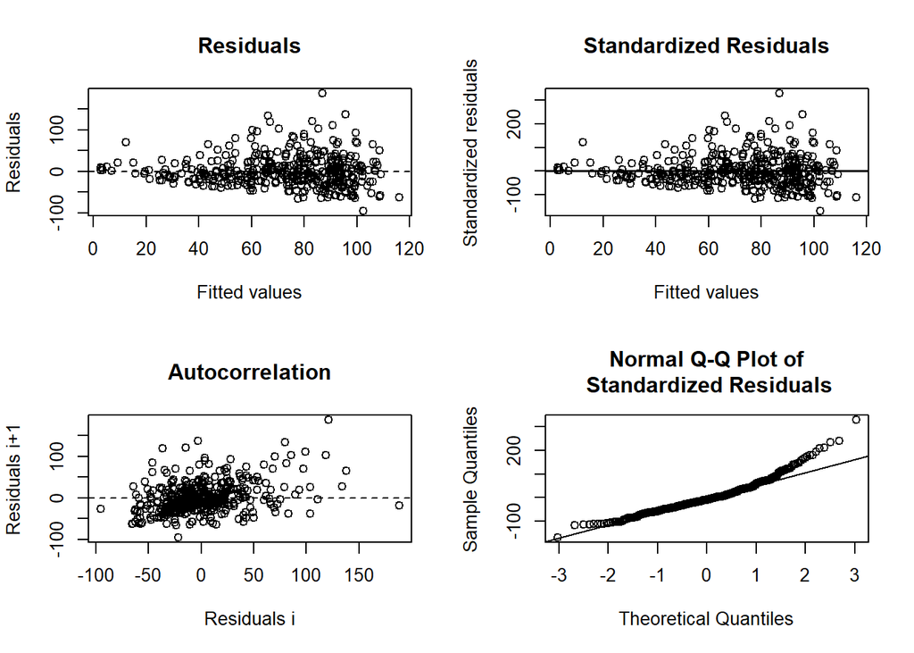

```
##
## ------
##  Shapiro-Wilk normality test
##
## data:  stdres
## W = 0.94297, p-value = 2.046e-11
##
##
## ------
```

```
##
##  Runs Test
##
## data:  as.factor(run)
## Standard Normal = -4.483, p-value = 7.36e-06
## alternative hypothesis: two.sided
```

## predict and plot

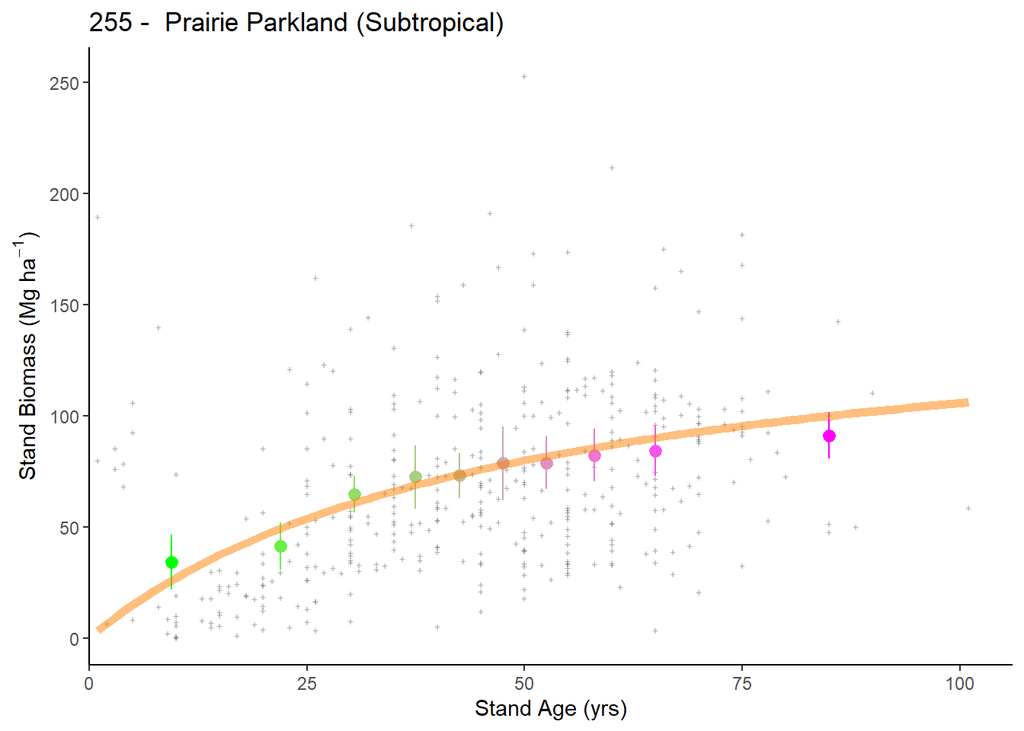

## plotting 2

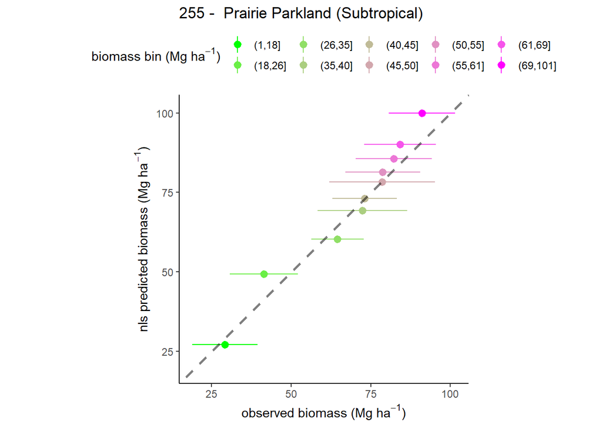

# 261 - California Coastal Chaparral Forest and Shrub

## model selection 1

[output not shown]

```
## Error in h(simpleError(msg, call)) :
##   error in evaluating the argument 'object' in selecting a method for function 'summary': object 'nls_261.' not found
```

### summary

- simple model: does not fit
- phi model: does not fit
- phi-alpha model: does not fit

## model selection 2

### summary

- add p model: does not fit
- add s model: does not fit
- add s+p model: does not fit
- unable to fit model (only 64 observations)

## plot residuals

```
## [1] "cannot plot residuals"
```

## predict and plot

```
## [1] "cannot plot data with prediction"
```

## plotting 2

```
## [1] "cannot plot observed vs. predicted"
```

# 262 - California Dry Steppe

## model selection 1

[output not shown]

```
## Error in h(simpleError(msg, call)) :
##   error in evaluating the argument 'object' in selecting a method for function 'summary': object 'nls_262.' not found
```

### summary

- simple model: does not fit
- phi model: does not fit
- phi-alpha model: does not fit

## model selection 2

### summary

- add p model: does not fit
- add s model: does not fit
- add s+p model: does not fit
- unable to fit model (0 observations)

## plot residuals

```
## [1] "cannot plot residuals"
```

## predict and plot

```
## [1] "cannot plot data with prediction"
```

## plotting 2

```
## [1] "cannot plot observed vs. predicted"
```

# 263 - California Coastal Steppe - Mixed Forest and Redwood Forest

## model selection 1

[output not shown]

```
## Error in h(simpleError(msg, call)) :
##   error in evaluating the argument 'object' in selecting a method for function 'summary': object 'nls_263.' not found
```

### summary

- simple model: does not fit
- phi model: does not fit
- phi-alpha model: does not fit

## model selection 2

### summary

- add p model: does not fit
- add s model: does not fit
- add s+p model: does not fit

## plot residuals

```
## [1] "cannot plot residuals"
```

## predict and plot

```
## [1] "cannot plot data with prediction"
```

## plotting 2

```
## [1] "cannot plot observed vs. predicted"
```

# 313 - Colorado Plateau Semi-Desert

## model selection 1

[output not shown]

```
## Error in h(simpleError(msg, call)) :
##   error in evaluating the argument 'object' in selecting a method for function 'summary': object 'nls_313.' not found
```

### summary

- simple model: does not fit
- phi model: does not fit
- phi-alpha model: does not fit

## model selection 2

### summary

- add p model: does not fit
- add s model: does not fit
- add s+p model: does not fit

## plot residuals

```
## [1] "cannot plot residuals"
```

## predict and plot

```
## [1] "cannot plot data with prediction"
```

## plotting 2

```
## [1] "cannot plot observed vs. predicted"
```

# 315 - Southwest Plateau and Plains Dry Steppe and Shrub

## model selection 1

### summary

- simple model: does not fit
- phi model: does not fit
- phi-alpha model: does not fit

## model selection 2

### summary

- add p model: does not fit
- add s model: does not fit
- add s+p model: does not fit

## plot residuals

```
## [1] "cannot plot residuals"
```

## predict and plot

```
## [1] "cannot plot data with prediction"
```

## plotting 2

```
## [1] "cannot plot observed vs. predicted"
```

# 321 - Chihuahuan Semi-Desert

## model selection 1

[output not shown]

```
## Error in h(simpleError(msg, call)) :
##   error in evaluating the argument 'object' in selecting a method for function 'summary': object 'nls_321.' not found
```

### summary

- simple model: does not fit
- phi model: does not fit
- phi-alpha model: does not fit

## model selection 2

### summary

- add p model: does not fit
- add s model: does not fit
- add s+p model: does not fit

## plot residuals

```
## [1] "cannot plot residuals"
```

## predict and plot

```
## [1] "cannot plot data with prediction"
```

## plotting 2

```
## [1] "cannot plot observed vs. predicted"
```

# 322 - American Semidesert and Desert

## model selection 1

```
## Error in if (any(nEQ <- vNms != make.names(vNms))) vNms[nEQ] <- paste0("`",  :
##   missing value where TRUE/FALSE needed
```

```
## Error in if (any(nEQ <- vNms != make.names(vNms))) vNms[nEQ] <- paste0("`",  :
##   missing value where TRUE/FALSE needed
```

```
## Error in if (any(nEQ <- vNms != make.names(vNms))) vNms[nEQ] <- paste0("`",  :
##   missing value where TRUE/FALSE needed
```

```
##   model AIC
## 1     1  NA
## 2     2  NA
## 3     3  NA
```

```
## Error in h(simpleError(msg, call)) :
##   error in evaluating the argument 'object' in selecting a method for function 'summary': object 'nls_322.' not found
```

### summary

- simple model: does not fit
- phi model: does not fit
- phi-alpha model: does not fit

## model selection 2

### summary

- add p model: does not fit
- add s model: does not fit
- add s+p model: does not fit

## plot residuals

```
## [1] "cannot plot residuals"
```

## predict and plot

```
## [1] "cannot plot data with prediction"
```

## plotting 2

```
## [1] "cannot plot observed vs. predicted"
```

- Cannot fit model
- not enough data (only 3 observations)

# 331 - Great Plains/Palouse Dry Steppe

## model selection 1

```
## Analysis of Variance Table
##
## Model 1: B_plt_t2_MgHa ~ (1 + (MEASTIME_t2 - 1990) * ge/100) * A * STDAGE_t2/(k + STDAGE_t2)
## Model 2: B_plt_t2_MgHa ~ (1 + (MEASTIME_t2 - 1990) * ge/100) * (1 + phi * DeltaPDSI) * A * STDAGE_t2/(k + STDAGE_t2)
## Model 3: B_plt_t2_MgHa ~ (1 + (MEASTIME_t2 - 1990) * ge/100) * (1 + phi * DeltaPDSI) * (1 - alpha * B_L_prop) * A * STDAGE_t2/(k + STDAGE_t2)
##   Res.Df Res.Sum Sq Df  Sum Sq F value Pr(>F)
## 1    100     41.314
## 2     99     41.190  1 0.12451  0.2993 0.5856
## 3     98     40.653  1 0.53687  1.2942 0.2580
##   model      AIC
## 1     1 1041.162
## 2     2 1042.851
## 3     3 1043.500
```

```
##
## Formula: B_plt_t2_MgHa ~ (1 + (MEASTIME_t2 - 1990) * ge/100) * A * STDAGE_t2/(k +
##     STDAGE_t2)
##
## Parameters:
##    Estimate Std. Error t value Pr(>|t|)
## ge    1.050      2.581   0.407    0.685
## A    63.462     42.287   1.501    0.137
## k    32.803     44.232   0.742    0.460
##
## Residual standard error: 0.6428 on 100 degrees of freedom
##
## Number of iterations to convergence: 6
## Achieved convergence tolerance: 7.174e-06
##   (1 observation deleted due to missingness)
```

### summary

- simple model: fits
- phi model: fits
- phi-alpha model: fits

## model selection 2

```
## Error in nls(get(paste("f_", Mod.Sel1, "a", sep = "")), data = G_331,  :
##   step factor 0.000488281 reduced below 'minFactor' of 0.000976562
## Error in nls(get(paste("f_", Mod.Sel1, "b", sep = "")), data = G_331,  :
##   step factor 0.000488281 reduced below 'minFactor' of 0.000976562
## Error in numericDeriv(form[[3L]], names(ind), env, central = nDcentral) :
##   Missing value or an infinity produced when evaluating the model
##   model      AIC
## 1     1 1041.162
## 2    1a       NA
## 3    1b       NA
## 4    1c       NA
```

```
##
## Formula: B_plt_t2_MgHa ~ (1 + (MEASTIME_t2 - 1990) * ge/100) * A * STDAGE_t2/(k +
##     STDAGE_t2)
##
## Parameters:
##    Estimate Std. Error t value Pr(>|t|)
## ge    1.050      2.581   0.407    0.685
## A    63.462     42.287   1.501    0.137
## k    32.803     44.232   0.742    0.460
##
## Residual standard error: 0.6428 on 100 degrees of freedom
##
## Number of iterations to convergence: 6
## Achieved convergence tolerance: 7.174e-06
##   (1 observation deleted due to missingness)
```

### summary

- add p model: does not fit
- add s model: does not fit
- add s+p model: does not fit

## plot residuals

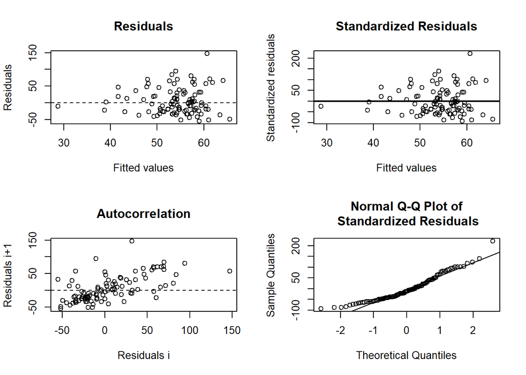

```
##
## ------
##  Shapiro-Wilk normality test
##
## data:  stdres
## W = 0.9365, p-value = 9.331e-05
##
##
## ------
```

```
##
##  Runs Test
##
## data:  as.factor(run)
## Standard Normal = -5.2422, p-value = 1.587e-07
## alternative hypothesis: two.sided
```